# Caracterización de Factores de Riesgo para Cáncer Colorrectal (CCR)

Análisis Exploratorio de Datos (EDA) en una Muestra de 57 Individuos

JP Carrasco, M.Vera, B.González, A.Hernández

2025-12-19

## Contexto

El Cáncer Colorrectal (CCR) representa uno de los desafíos de salud pública más significativos a nivel global. Según datos de la Agencia Internacional para la Investigación del Cáncer (IARC) y reportes de GLOBOCAN, el CCR es el tercer tipo de cáncer más diagnosticado en el mundo y la segunda causa principal de muerte por cáncer.

La etiología del CCR es multifactorial, involucrando una interacción compleja entre factores genéticos no modificables (edad, antecedentes familiares) y factores de estilo de vida modificables. Organizaciones como el World Cancer Research Fund (WCRF) han establecido evidencia convincente de que el consumo de tabaco, alcohol, carnes procesadas y la obesidad corporal incrementan el riesgo, mientras que la actividad física actúa como un potente factor protector.

## Objetivo del Análisis

El objetivo es caracterizar la muestra en función de:

[output not shown]

Este informe examina la estructura, calidad y patrones identificados en el conjunto de datos de evaluación de riesgo de Cáncer Colorrectal (CCR).

Informe Analítico: Estratificación de Riesgo CCR

El análisis de los registros revela una segmentación clara de la población en tres categorías de riesgo (“Bajo”, “Moderado”, “Alto”), impulsada por una lógica algorítmica visible en los datos:

El Factor “Edad” como Discriminante Basal: Se observa una fuerte correlación entre la edad avanzada y el nivel de riesgo. La mayoría de los pacientes mayores de 45 años son clasificados automáticamente, al menos, en Riesgo Moderado, independientemente de la ausencia de síntomas. Un ejemplo claro es el caso del paciente ID 2 (79 años) o ID 5 (63 años), quienes, a pesar de no presentar síntomas de alarma ni antecedentes familiares directos reportados, mantienen un riesgo moderado.

Sintomatología de Alarma sobre Datos Demográficos: Un hallazgo crítico es la presencia de Riesgo Alto en pacientes jóvenes (2).

Por ejemplo, el paciente ID 1 es un hombre joven de 25 años. Bajo una segmentación tradicional por edad, sería de bajo riesgo. Sin embargo, debido a la presencia de sangre en las deposiciones (variable ccr_c_sangre: “Si”), la categorización de riesgo lo eleva correctamente a Riesgo Alto.

Patrón similar se observa en el paciente ID 38 (33 años), clasificado en Riesgo Alto asociado a sintomatología, a pesar de su juventud.

Estilos de Vida y Comorbilidades: Existe una prevalencia notable de malnutrición por exceso en la muestra. Múltiples registros con categorías de Sobrepeso y Obesidad se correlacionan transversalmente con todos los niveles de riesgo. Aunque el IMC (Índice de Masa Corporal) es un factor de salud general, en este conjunto de datos parece actuar como una variable descriptiva secundaria frente a los determinantes fuertes (edad y sangrado).

En resumen, la muestra presenta una distribución balanceada que permite acciones diferenciadas: educación preventiva para el grupo de Riesgo Bajo y derivación clínica inmediata para el grupo de Riesgo Alto.

## Carga y Preparación de datos

Para este análisis, se utilizan las librerías del ecosistema tidyverse para manipulación y visualización, janitor para limpieza de metadatos y ggthemes para estética.

```r
library(tidyverse)
library(janitor) # es excelente para limpiar nombres de columnas
library(forcats) # es útil para manipular variables categóricas (factores)
library(dplyr)
library(tidyr)
library(knitr)
library(ggplot2)
library(ggthemes)
library(scales)
library(readr)
library(readxl)
library(glue)
library(kableExtra)
library(stringi)
library(gridExtra)
```

```r
# Utiliza el dataset_R de la carpeta compartida
url_raw <- "https://raw.githubusercontent.com/jpcl-cl/vcm_ccr/main/data_ccr_vcm.csv"

# Leemos el archivo
data <- read_csv2(url_raw, locale = locale(encoding = "ISO-8859-1"))

# Verificación
#glimpse(data)

#Library(glue)
print(glue("El set de datos tiene {ncol(data)} categorías que represetan las preguntas realizadas en la encuesta y {nrow(data)} observaciones, correspondientes a la cantidad de encuestados"))
```

```
## El set de datos tiene 30 categorías que represetan las preguntas realizadas en la encuesta y 57 observaciones, correspondientes a la cantidad de encuestados
```

```r
# Limpieza inicial y estandarización de nombres
data <- data %>%
  clean_names() %>%
  select(-id, -fono) %>% # Eliminación de identificadores personales
  mutate(
    # Imputación de NAs en antecedentes familiares menores de 50 años
    ccr_a_fam50 = replace_na(ccr_a_fam50, "No"),
    # Ordenamiento lógico de la variable ordinal de Riesgo
    riesgo = factor(riesgo, levels = c("Riesgo bajo", "Riesgo moderado", "Riesgo Alto"))
  )
```

## Descripción General de la Muestra

A continuación, se presenta una tabla descriptiva de las variables demográficas clave para contextualizar la población estudiada.

```r
# Creación de tabla resumen demográfica

tabla_resumen <- data %>%
  group_by(genero) %>%
  summarise(
    N = n(),
    Edad_Promedio = round(mean(edad), 1),
    Edad_Min = min(edad),
    Edad_Max = max(edad),
    Porcentaje = round(n() / nrow(data) * 100, 1)
  )

kable(tabla_resumen,
      caption = "Tabla 1: Perfil Demográfico de la Muestra por Género",
      align = "c",
      col.names = c("Género", "N", "Edad Media", "Mín", "Máx", " Total (%)"))
```

Tabla 1: Perfil Demográfico de la Muestra por Género

| Género | N | Edad Media | Mín | Máx | Total (%) |
| --- | --- | --- | --- | --- | --- |
| Hombre | 30 | 53.8 | 25 | 91 | 52.6 |
| Mujer | 27 | 58.9 | 28 | 87 | 47.4 |

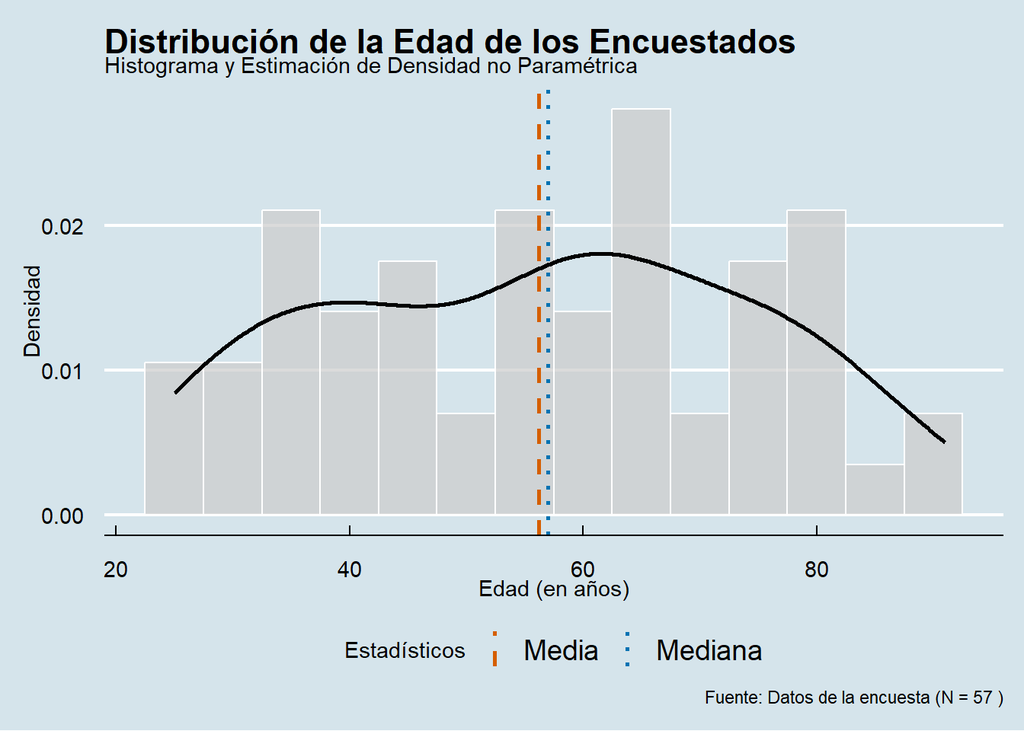

```r
# 2. Crear el gráfico

stats_edad <- data %>%
  summarise(
    media = mean(edad),
    mediana = median(edad),
    n = n()
  )

ggplot(data, aes(x = edad)) +
    geom_histogram(
    aes(y = ..density..),
    binwidth = 5,
    fill = "grey80", # relleno neutro
    color = "white", # Borde de las barras
    alpha = 0.7
  ) +
    geom_density(color = "black", size = 1) +             # Línea de densidad (en negro sólido)
    geom_vline(                                           # Añadir líneas verticales para Media y Mediana
    aes(xintercept = stats_edad$media, color = "Media"),  # Mapeamos 'color' dentro de aes() para que se genere una leyenda
    linetype = "dashed",                                  # Línea discontinua
    size = 1
  ) +
  geom_vline(
    aes(xintercept = stats_edad$mediana, color = "Mediana"),
    linetype = "dotted",                                  # Línea punteada
    size = 1
  ) +

  scale_color_manual(                                     # Definir los colores y el título de la leyenda de las líneas
    name = "Estadísticos",
    values = c("Media" = "#d55e00", "Mediana" = "#0072b2") # Colores
  ) +
                                                            # Títulos y etiquetas (labs) más formales
  labs(
    title = "Distribución de la Edad de los Encuestados",
    subtitle = "Histograma y Estimación de Densidad no Paramétrica",
    x = "Edad (en años)",
    y = "Densidad",
    caption = paste("Fuente: Datos de la encuesta (N =", stats_edad$n, ")")
  ) +

  theme_economist() +
    theme(legend.position = "bottom")                     # La movemos la leyenda abajo para no interferir con el gráfico.
```

La tabla y el gráfico muestran la distribución por sexo y los rangos etarios. Dado que **la edad es el principal factor de riesgo no modificable para el CCR (aumentando exponencialmente desde los 50 años), la media de edad de la muestra es un indicador clave para la interpretación de los niveles de riesgo encontrados**.

```r
# -----------------------------------------------------------------------------
# 1. LIBRERÍAS Y CONFIGURACIÓN
datos <- data %>%
    mutate(
      # 1. Edad > 45: Corregir "Si" por "Sí"
      edad_45 = case_when(
        edad_45 == "Si" ~ "Sí",
        edad_45 == "No" ~ "No",
        TRUE ~ edad_45
      ),
      # 2. Salud: Normalizar mayúsculas de FONASA y tildes
      seg_salud = case_when(
        str_detect(seg_salud, regex("Fonasa", ignore_case = TRUE)) ~ str_replace(seg_salud, regex("Fonasa", ignore_case = TRUE), "FONASA"),
        seg_salud == "Sin afiliación" ~ "Sin Afiliación",
        seg_salud == "No sabe" ~ "Desconoce",
        TRUE ~ seg_salud
      ),
      # 3. Educación: Normalizar BÃ¡sico (completo/incompleto)
      ccr_s_educ = str_replace(ccr_s_educ,
                             pattern = fixed("BÃ¡sico (completo/incompleto)"),
                             replacement = "Basico (completo/incompleto)"),
        # 4. JJVV: Asegurar tilde en Sí
      jjvv = case_when(
        jjvv == "Si" ~ "Sí",
        TRUE ~ jjvv
      )
    )
```

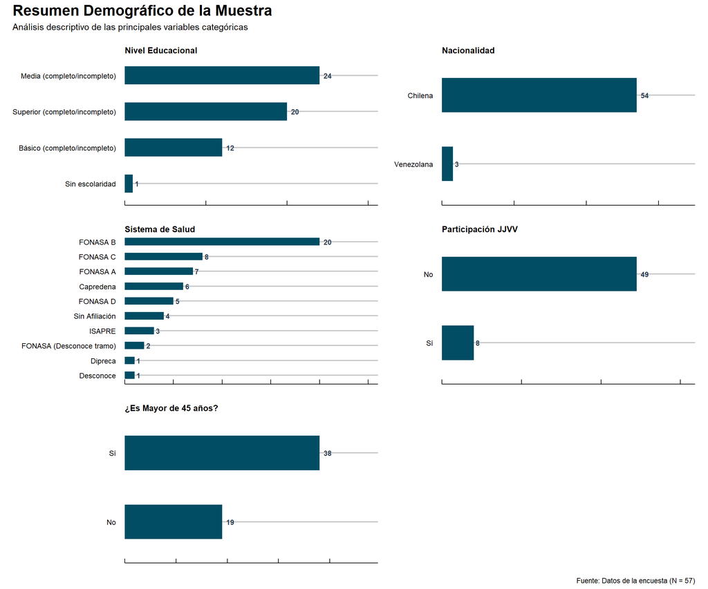

```r
library(patchwork) # Necesario para la grilla

generate_analysis_economist <- function(datos, col_cat, col_num, title, label_x, imprimir_tabla = TRUE) {

  # A. TABLA RESUMEN
  if(imprimir_tabla) {
    tabla_resumen <- datos %>%
      filter(!is.na(!!sym(col_cat))) %>%
      group_by(!!sym(col_cat)) %>%
      summarise(
        N = n(),
        Edad_Media = round(mean(!!sym(col_num), na.rm = TRUE), 1),
        Min = min(!!sym(col_num), na.rm = TRUE),
        Max = max(!!sym(col_num), na.rm = TRUE)
      ) %>%
      mutate(Total_Pct = paste0(round(N / sum(N) * 100, 1), "%")) %>%
      arrange(desc(N))

    print(kable(tabla_resumen,
          caption = paste("Tabla:", title),
          align = "c",
          col.names = c(label_x, "N", "Edad Media", "Mín", "Máx", "Total (%)")))
  }

  # B. PREPARACIÓN DATOS GRÁFICO (Re-calculamos para el plot)
  plot_data <- datos %>%
    filter(!is.na(!!sym(col_cat))) %>%
    count(!!sym(col_cat)) %>%
    arrange(desc(n))

  # C. GRÁFICO
  p <- ggplot(plot_data, aes(x = reorder(!!sym(col_cat), n), y = n)) +
    geom_col(fill = "#014d64", width = 0.5) +
    geom_text(aes(label = n), hjust = -0.5, size = 3, fontface = "bold", color = "#2c3e50") +
    scale_y_continuous(expand = expansion(mult = c(0, 0.3))) + # Más espacio para etiquetas
    coord_flip() +
    labs(
      title = str_wrap(title, 25), # Ajustar títulos largos para que quepan en la grilla
      x = NULL, y = NULL
    ) +
    theme_economist_white(gray_bg = FALSE) +
    theme(
      plot.title = element_text(size = 10, face = "bold"),
      axis.text.y = element_text(size = 9, hjust = 1),
      axis.text.x = element_blank(), # Quitamos eje X numérico para limpiar la grilla
      panel.grid = element_blank()   # Limpiamos fondo
    )

  return(p) # Retornamos el objeto para poder guardarlo
}


# 1. Generamos y guardamos cada gráfico en una variable
# Nota: 'imprimir_tabla = FALSE' para que no salgan las tablas mezcladas,
# si quieres las tablas, pon TRUE o sácalas en un chunk aparte.

g1 <- generate_analysis_economist(datos, "ccr_s_educ", "edad", "Nivel Educacional", "Nivel", imprimir_tabla = FALSE)
g2 <- generate_analysis_economist(datos, "ccr_s_nac", "edad", "Nacionalidad", "País", imprimir_tabla = FALSE)
g3 <- generate_analysis_economist(datos, "seg_salud", "edad", "Sistema de Salud", "Previsión", imprimir_tabla = FALSE)
g4 <- generate_analysis_economist(datos, "jjvv", "edad", "Participación JJVV", "JJVV", imprimir_tabla = FALSE)
g5 <- generate_analysis_economist(datos, "edad_45", "edad", "¿Es Mayor de 45 años?", "Edad > 45", imprimir_tabla = FALSE)

# 2. Creamos la grilla 3x2 con patchwork
# La sintaxis es simple: g1 + g2 + ... + plot_layout()

(g1 + g2 + g3 + g4 + g5) +
  plot_layout(ncol = 2, nrow = 3) +
  plot_annotation(
    title = 'Resumen Demográfico de la Muestra',
    subtitle = 'Análisis descriptivo de las principales variables categóricas',
    caption = 'Fuente: Datos de la encuesta (N = 57)',
    theme = theme(plot.title = element_text(size = 18, face = "bold"))
  )
```

## Antecedentes de los encuestados

### Colonoscopias previas

Pregunta de la encuesta: ¿Ha tenido colonoscopias previas?

```r
data_a_ccr <- data %>%
  mutate(
    # Crear variable de grupo etario (Corte en 45 años)
    Grupo_Edad = if_else(edad >= 45, "45 años o más", "Menor de 45 años"),

    # Estandarizar la variable de interés (Colonoscopía)
    # Asumimos que "Sí" = Se realizó colonoscopía, "No" = No se realizó
  estado_colonoscopia = factor(ccr_a_colon,
                                 levels = c("Sí", "Si", "No"),
                                 labels = c("Sí", "Sí", "No"))
  )

# ---------------------------------------------------------
# 4. Creación de la Tabla Profesional (Estilo Académico)
# ---------------------------------------------------------
tabla_resumen_colon <- data_a_ccr %>%
  group_by(Grupo_Edad, ccr_a_colon) %>%
  summarise(Frecuencia = n(), .groups = 'drop') %>%
  mutate(
    Porcentaje = round((Frecuencia / sum(Frecuencia)) * 100, 1)
  )

# Agregamos la fila de Totales
tabla_final_colon <- tabla_resumen_colon %>%
  bind_rows(
    summarise(.,
              Grupo_Edad = "Total",
              ccr_a_colon = "",
              Frecuencia = sum(Frecuencia),
              Porcentaje = sum(Porcentaje))
  ) %>%
  rename(
    "Grupo Etario" = Grupo_Edad,
    "¿Antecedentes Cáncer de Colon?" = ccr_a_colon, # Nombre ajustado a la variable
    "N° Casos" = Frecuencia,
    "% del Total" = Porcentaje
  )

# Renderizamos
tabla_kable_colon <- kable(tabla_final_colon,
                           caption = "Tabla 2: Antecedentes de Cáncer de Colon por Grupo Etario",
                           align = "lccc",
                           booktabs = TRUE) %>%
  kable_styling(full_width = FALSE, position = "left") %>%
  row_spec(0, bold = TRUE) %>%
  row_spec(nrow(tabla_final_colon), bold = TRUE, background = "#f5f5f5")

# Mostrar tabla
tabla_kable_colon
```

| Grupo Etario | ¿Antecedentes Cáncer de Colon? | N° Casos | % del Total |
| --- | --- | --- | --- |
| 45 años o más | No | 25 | 43.9 |
| 45 años o más | Sí | 13 | 22.8 |
| Menor de 45 años | No | 19 | 33.3 |
| Total |  | 57 | 100.0 |

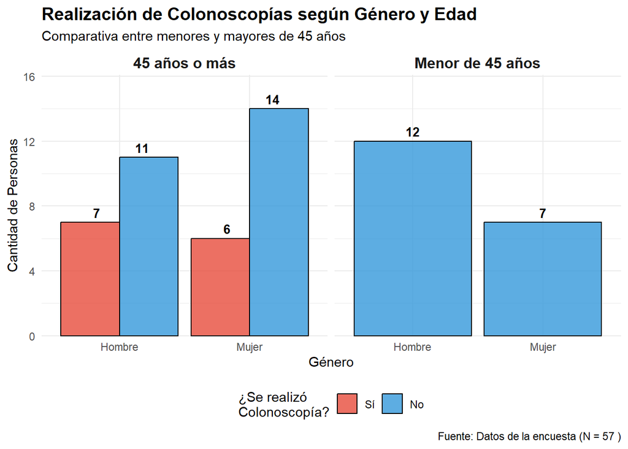

```r
# ---------------------------------------------------------
# 5. Creación del Gráfico
# ---------------------------------------------------------
grafico_colon <- ggplot(data_a_ccr, aes(x = genero, fill = estado_colonoscopia)) +
  # Usamos position = "dodge" para barras una al lado de la otra
  geom_bar(position = "dodge", color = "black", alpha = 0.8) +
  geom_text(
    stat = "count",                           # Calcula el conteo automáticamente
    aes(label = after_stat(count)),           # Usa ese conteo como etiqueta
    position = position_dodge(width = 0.7),   # Se mueve igual que las barras (mismo width)
    vjust = -0.5,                             # Posición vertical: un poco arriba de la barra
    size = 3.5,                               # Tamaño legible
    fontface = "bold",                        # Negrita para destacar
    color = "black"                           # Color del texto
  ) +
  facet_wrap(~Grupo_Edad) +
  scale_y_continuous(expand = expansion(mult = c(0, 0.15))) +

  # Etiquetas y Títulos Profesionales
  labs(
    title = "Realización de Colonoscopías según Género y Edad",
    subtitle = "Comparativa entre menores y mayores de 45 años",
    x = "Género",
    y = "Cantidad de Personas",
    fill = "¿Se realizó\nColonoscopía?",
    caption = paste("Fuente: Datos de la encuesta (N =", stats_edad$n, ")")
  ) +

  # Estilo visual limpio
  theme_minimal() +
  scale_fill_manual(values = c("Sí" = "#E74C3C", "No" = "#3498DB")) + # Rojo para Sí, Azul para No
  theme(
    plot.title = element_text(face = "bold", size = 14),
    strip.text = element_text(face = "bold", size = 12), # Texto de los paneles
    legend.position = "bottom"
  )

# Mostrar el gráfico
print(grafico_colon)
```

### Pólipos

Pregunta de la encuesta: ¿Está actualmente bajo vigilancia médica por pólipos en el colon o recto?

```r
datos_polip <- data %>%
  mutate(
    Grupo_Edad = ifelse(edad >= 45, "Mayor de 45 años", "45 años o menos"),
    Grupo_Edad = factor(Grupo_Edad, levels = c("Mayor de 45 años", "45 años o menos")),
    ccr_a_polip = as.factor(ccr_a_polip)
  ) %>%
  # Filtramos valores nulos en género si es necesario para limpieza visual
  filter(!is.na(genero))

#2. Creación de la Tabla Resumen
# -----------------------------------------------------------------------------

tabla_resumen_polip <- datos_polip %>%
  group_by(Grupo_Edad, ccr_a_polip) %>%
  summarise(Frecuencia = n(), .groups = 'drop') %>%
  mutate(
    Porcentaje = round((Frecuencia / sum(Frecuencia)) * 100, 1)
  )

# Agregamos la fila de Totales
tabla_final_polip <- tabla_resumen_polip %>%
  bind_rows(
    summarise(.,
              Grupo_Edad = "Total",
              ccr_a_polip = "",
              Frecuencia = sum(Frecuencia),
              Porcentaje = sum(Porcentaje))
  ) %>%
  rename(
    "Grupo Etario" = Grupo_Edad,
    "¿Antecedentes de Pólipos?" = ccr_a_polip, # Nombre de columna actualizado
    "N° Casos" = Frecuencia,
    "% del Total" = Porcentaje
  )

# Renderizamos manteniendo la estética
tabla_kable_polip <- kable(tabla_final_polip,
                           caption = "Tabla 3: Antecedentes de Pólipos por Grupo Etario", # Título actualizado
                           align = "lccc",
                           booktabs = TRUE) %>%
  kable_styling(full_width = FALSE, position = "left") %>%
  row_spec(0, bold = TRUE) %>%
  row_spec(nrow(tabla_final_polip), bold = TRUE, background = "#f5f5f5")

# Mostrar tabla
tabla_kable_polip
```

Tabla 3: Antecedentes de Pólipos por Grupo Etario

| Grupo Etario | ¿Antecedentes de Pólipos? | N° Casos | % del Total |
| --- | --- | --- | --- |
| Mayor de 45 años | No | 34 | 59.6 |
| Mayor de 45 años | Si | 2 | 3.5 |
| Mayor de 45 años | NA | 2 | 3.5 |
| 45 años o menos | No | 19 | 33.3 |
| Total |  | 57 | 99.9 |

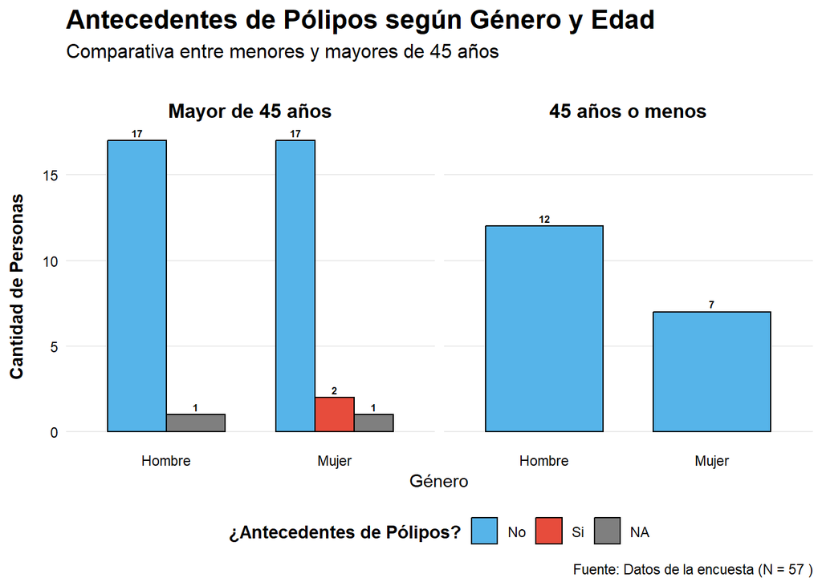

```r
# -----------------------------------------------------------------------------
# Paso 3: Creación del Gráfico (Visualization)
# -----------------------------------------------------------------------------
graf_polip <- ggplot(datos_polip, aes(x = genero, fill = ccr_a_polip)) +

  # Geometría de barras: posición 'dodge' para ponerlas lado a lado, color negro para el borde
  geom_bar(position = "dodge", color = "black", width = 0.7) +
  geom_text(
    stat = "count",                           # Calcula el conteo automáticamente
    aes(label = after_stat(count)),           # Usa ese conteo como etiqueta
    position = position_dodge(width = 0.7),   # Se mueve igual que las barras (mismo width)
    vjust = -0.5,                             # Posición vertical: un poco arriba de la barra
    size = 2.1,                               # Tamaño legible
    fontface = "bold",                        # Negrita para destacar
    color = "black"                           # Color del texto
  ) +
  # Facetas: Dividir el gráfico en dos paneles según el grupo de edad
  facet_wrap(~Grupo_Edad) +

  # Escala de colores manual para replicar el estilo (Azul y Gris)
  # Nota: Ajusta el orden de los colores según tus valores (ej. No = Azul, Si = rojo)
  scale_fill_manual(values = c("#56B4E9", "#E74C3C")) +

  # Etiquetas y textos idénticos al estilo solicitado
  labs(
    title = "Antecedentes de Pólipos según Género y Edad",
    subtitle = "Comparativa entre menores y mayores de 45 años",
    y = "Cantidad de Personas",
    x = "Género",
    fill = "¿Antecedentes de Pólipos?", # Adaptamos la leyenda a la nueva variable
    caption = paste("Fuente: Datos de la encuesta (N =", stats_edad$n, ")")
  ) +

  # Tema visual: Minimalista con ajustes finos para igualar la imagen
  theme_minimal() +
  theme(
    plot.title = element_text(face = "bold", size = 16, hjust = 0),
    plot.subtitle = element_text(size = 12, margin = margin(b = 20)),
    strip.text = element_text(face = "bold", size = 12, color = "black"), # Texto de las facetas (45 años...)
    axis.title.y = element_text(face = "bold", margin = margin(r = 10)),
    axis.text = element_text(color = "black"),
    legend.position = "bottom", # Leyenda abajo como en la imagen
    legend.title = element_text(face = "bold"),
    panel.grid.major.x = element_blank(), # Eliminamos líneas verticales para limpieza
    panel.grid.minor = element_blank()
  )

# -----------------------------------------------------------------------------
# Paso 4: Renderizar
# -----------------------------------------------------------------------------
print(graf_polip)
```

El gráfico revela una **baja prevalencia de antecedentes reportados de pólipos en la población encuestada**.

El total de los casos positivos (respuesta “Sí”) se encuentran exclusivamente en el segmento de “45 años o más”.

En esta muestra específica, los únicos casos afirmativos corresponden al género Femenino *(específicamente los registros con ID 25 y 40)*.

### Diagnóstico de Enfermedades inflamatorias intestinales.

Pregunta de la encuesta: ¿Le han diagnosticado enfermedad inflamatoria intestinal (como la enfermedad de Crohn o colitis ulcerosa)?

```r
datos_eii <- data %>%
  mutate(
    Grupo_Edad = ifelse(edad >= 45, "45 años o más", "Menor de 45 años"),
    Grupo_Edad = factor(Grupo_Edad, levels = c("45 años o más", "Menor de 45 años")),
    # Variable objetivo: Antecedentes de EII
    ccr_a_eii = as.factor(ccr_a_eii)
  ) %>%
  filter(!is.na(genero) & !is.na(ccr_a_eii))

# -----------------------------------------------------------------------------
# Creación de la Tabla 3
# -----------------------------------------------------------------------------

tabla_resumen_eii <- datos_eii %>%
  group_by(Grupo_Edad, ccr_a_eii) %>%
  summarise(Frecuencia = n(), .groups = 'drop') %>%
  mutate(
    Porcentaje = round((Frecuencia / sum(Frecuencia)) * 100, 1)
  )

# Agregamos la fila de Totales
tabla_final_eii <- tabla_resumen_eii %>%
  bind_rows(
    summarise(.,
              Grupo_Edad = "Total",
              ccr_a_eii = "",
              Frecuencia = sum(Frecuencia),
              Porcentaje = sum(Porcentaje))
  ) %>%
  rename(
    "Grupo Etario" = Grupo_Edad,
    "¿Antecedentes EII?" = ccr_a_eii,
    "N° Casos" = Frecuencia,
    "% del Total" = Porcentaje
  )

# Renderizamos
tabla_kable_eii <- kable(tabla_final_eii,
                         caption = "Tabla 4: Antecedentes de Enfermedad Inflamatoria Intestinal (EII) por Grupo Etario",
                         align = "lccc",
                         booktabs = TRUE) %>%
  kable_styling(full_width = FALSE, position = "left") %>%
  row_spec(0, bold = TRUE) %>%
  row_spec(nrow(tabla_final_eii), bold = TRUE, background = "#f5f5f5")
tabla_kable_eii
```

Tabla 4: Antecedentes de Enfermedad Inflamatoria Intestinal (EII) por Grupo Etario

| Grupo Etario | ¿Antecedentes EII? | N° Casos | % del Total |
| --- | --- | --- | --- |
| 45 años o más | No | 38 | 66.7 |
| Menor de 45 años | No | 19 | 33.3 |
| Total |  | 57 | 100.0 |

```r
#print(tabla_kable_eii)
```

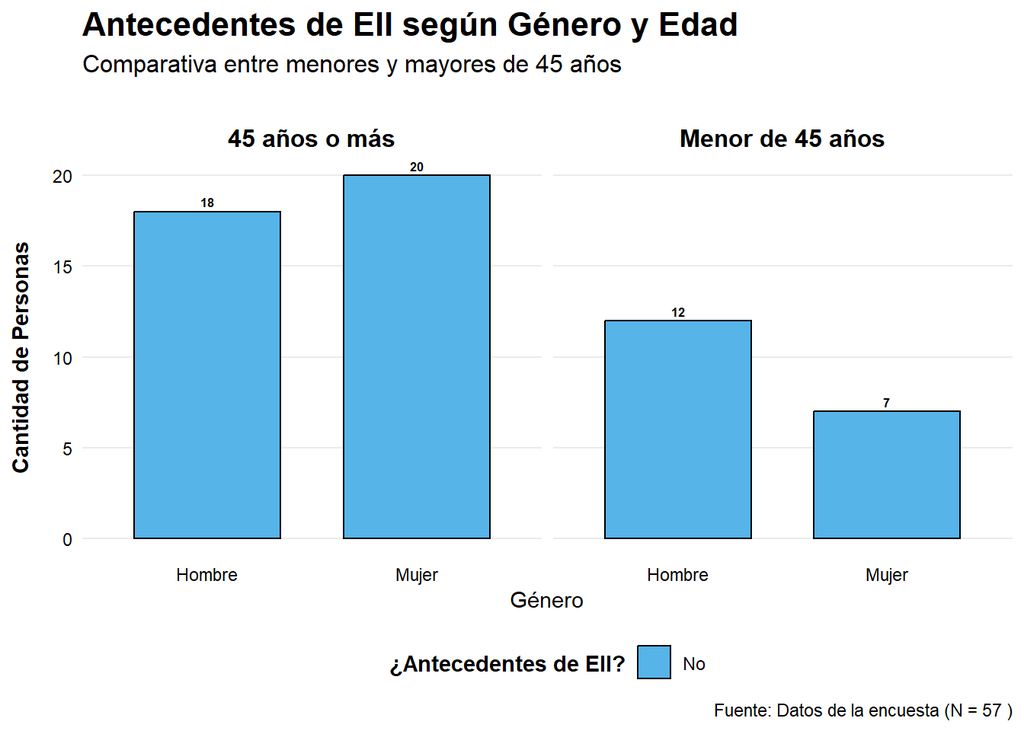

```r
# -----------------------------------------------------------------------------
# Creación del gráfico 3
# -----------------------------------------------------------------------------

grafico_eii <- ggplot(datos_eii, aes(x = genero, fill = ccr_a_eii)) +
  geom_bar(position = "dodge", color = "black", width = 0.7) +
  geom_text(
    stat = "count",                           # Calcula el conteo automáticamente
    aes(label = after_stat(count)),           # Usa ese conteo como etiqueta
    position = position_dodge(width = 0.7),   # Se mueve igual que las barras (mismo width)
    vjust = -0.5,                             # Posición vertical: un poco arriba de la barra
    size = 2.1,                               # Tamaño legible
    fontface = "bold",                        # Negrita para destacar
    color = "black"                           # Color del texto
  ) +
  facet_wrap(~Grupo_Edad) +
  # Mantenemos la paleta de colores corporativa/sobria
  scale_fill_manual(values = c("#56B4E9", "#999999")) +
  labs(
    title = "Antecedentes de EII según Género y Edad",
    subtitle = "Comparativa entre menores y mayores de 45 años",
    y = "Cantidad de Personas",
    x = "Género",
    fill = "¿Antecedentes de EII?",
    caption = paste("Fuente: Datos de la encuesta (N =", stats_edad$n, ")")
  ) +
  theme_minimal() +
  theme(
    plot.title = element_text(face = "bold", size = 16, hjust = 0),
    plot.subtitle = element_text(size = 12, margin = margin(b = 20)),
    strip.text = element_text(face = "bold", size = 12, color = "black"),
    axis.title.y = element_text(face = "bold", margin = margin(r = 10)),
    axis.text = element_text(color = "black"),
    legend.position = "bottom",
    legend.title = element_text(face = "bold"),
    panel.grid.major.x = element_blank(),
    panel.grid.minor = element_blank()
  )

print(grafico_eii)
```

Tanto la gráfica como la tabla demuestran que no existen casos de encuestados con diagnóstico de enfermedades inflamatoria intestinal.

### Familiares con diagnóstico CCR

Pregunta de la encuesta: ¿Tiene algún familiar de primer grado (padres, hermanos, hijos) que haya sido diagnosticado con cáncer colorrectal?

```r
datos_fam <- data %>%
  mutate(
    Grupo_Edad = ifelse(edad >= 45, "45 años o más", "Menor de 45 años"),
    Grupo_Edad = factor(Grupo_Edad, levels = c("45 años o más", "Menor de 45 años")),
    # Variable objetivo: Antecedentes de EII
    ccr_a_eii = as.factor(ccr_a_fam)
  ) %>%
  filter(!is.na(genero) & !is.na(ccr_a_fam))

# -----------------------------------------------------------------------------
# Creación de la Tabla 4
# -----------------------------------------------------------------------------

tabla_resumen_fam <- datos_fam %>%
  group_by(Grupo_Edad, ccr_a_fam) %>%
  summarise(Frecuencia = n(), .groups = 'drop') %>%
  mutate(
    Porcentaje = round((Frecuencia / sum(Frecuencia)) * 100, 1)) %>%
  # Interpretación clínica rápida para la tabla
  rename(
    "Grupo Etario" = Grupo_Edad,
    "¿Antecedentes familiares?" = ccr_a_fam,
    "N° Casos" = Frecuencia,
    "% del Total" = Porcentaje
  )

# Renderizamos la tabla con estilo "Paper Académico" (Líneas horizontales limpias)
# kable() crea la estructura y kable_styling() aplica el formato visual
tabla_fam <- kable(tabla_resumen,
                     caption = "Tabla 5: Antecedentes familiares con dignóstico por                               CCR por Grupo Etario",
                     align = "lccc", # Alineación: Izquierda, Centro, Centro, Centro
                     booktabs = TRUE) %>% # booktabs = TRUE activa el estilo de líneas académicas (LaTeX style)
  kable_styling(full_width = FALSE, position = "left") %>%
  row_spec(0, bold = TRUE) # Negrita en encabezados
tabla_fam
```

[output not shown]

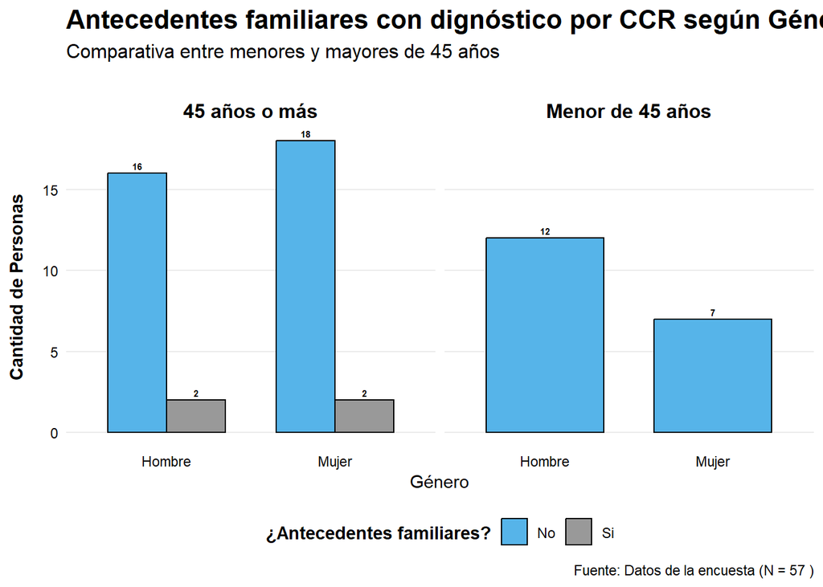

```r
# -----------------------------------------------------------------------------
# Creación del gráfico 4
# -----------------------------------------------------------------------------

grafico_fam <- ggplot(datos_fam, aes(x = genero, fill = ccr_a_eii)) +
  geom_bar(position = "dodge", color = "black", width = 0.7) +
  geom_text(
    stat = "count",                           # Calcula el conteo automáticamente
    aes(label = after_stat(count)),           # Usa ese conteo como etiqueta
    position = position_dodge(width = 0.7),   # Se mueve igual que las barras (mismo width)
    vjust = -0.5,                             # Posición vertical: un poco arriba de la barra
    size = 2.0,                               # Tamaño legible
    fontface = "bold",                        # Negrita para destacar
    color = "black"                           # Color del texto
  ) +
  facet_wrap(~Grupo_Edad) +
  # Mantenemos la paleta de colores corporativa/sobria
  scale_fill_manual(values = c("#56B4E9", "#999999")) +
  labs(
    title = "Antecedentes familiares con dignóstico por CCR según Género y Edad",
    subtitle = "Comparativa entre menores y mayores de 45 años",
    y = "Cantidad de Personas",
    x = "Género",
    fill = "¿Antecedentes familiares?",
    caption = paste("Fuente: Datos de la encuesta (N =", stats_edad$n, ")")
  ) +
  theme_minimal() +
  theme(
    plot.title = element_text(face = "bold", size = 16, hjust = 0),
    plot.subtitle = element_text(size = 12, margin = margin(b = 20)),
    strip.text = element_text(face = "bold", size = 12, color = "black"),
    axis.title.y = element_text(face = "bold", margin = margin(r = 10)),
    axis.text = element_text(color = "black"),
    legend.position = "bottom",
    legend.title = element_text(face = "bold"),
    panel.grid.major.x = element_blank(),
    panel.grid.minor = element_blank()
  )
grafico_fam
```

## Hábitos

### Estado Nutricional

La evidencia científica establece que el estado nutricional, específicamente el exceso de adiposidad, medido a través del Indice de Masa Corporal (IMC) actúa como un factor proinflamatorio crónico que eleva el riesgo de carcinogénesis colorrectal.

El Índice de Masa Corporal (IMC) funciona como un indicador antropométrico clave para estimar la adiposidad corporal, la cual está intrínsecamente ligada al balance energético del individuo.

Conceptualmente, un IMC elevado (categorizado como sobrepeso $\ge$ 25 kg/m² u obesidad $\ge$ 30 kg/m²) suele ser la manifestación clínica de un superávit calórico sostenido, derivado primariamente de hábitos alimenticios “obesogénicos” (Organización Mundial de la Salud [OMS], 2024).

Estos patrones dietéticos se caracterizan por el consumo frecuente de alimentos ultraprocesados, bebidas azucaradas y productos de alta densidad energética, los cuales alteran los mecanismos de saciedad y promueven una acumulación excesiva de tejido adiposo (Olivares Orrego et al., 2022). Por consiguiente, **el IMC no es solo una medida de peso, sino un marcador indirecto de la calidad de la dieta, donde la ingesta desproporcionada de grasas saturadas y azúcares refinados, frente a un bajo consumo de fibra y micronutrientes, actúa como el determinante fisiopatológico central del aumento ponderal** (National Heart, Lung, and Blood Institute [NHLBI], 2022).

Por esto, en el análisis se ha realizado, en base a la medición del IMC, una pregunta que busca clasificar a la muestra de acuerdo a este índice. Según los criterios de la OMS, la clasificación del Estado Nutrición según IMC es:

```r
# Crear los datos teóricos (Criterio OMS)
datos_teoricos <- data.frame(
  Clasificacion = c("Bajo peso", "Peso normal", "Sobrepeso", "Obesidad"),
  Rango_IMC = c("< 18.5", "18.5 – 24.9", "25.0 – 29.9", "≥ 30.0"),
  Descripcion_Riesgo = c("Bajo (pero riesgo de otros problemas)",
                         "Promedio",
                         "Aumentado",
                         "Moderado a Muy Alto")
)

# 3. Generar la tabla con el estilo de la imagen
tabla2 <- datos_teoricos %>%
  kbl(
    col.names = c("Clasificación", "IMC (kg/m²)", "Riesgo de Comorbilidades"),
    align = c("l", "c", "l"), # l=izquierda, c=centro
    caption = "Tabla 6: Clasificación del Estado Nutricional según IMC (Criterio OMS)"
  ) %>%
  # kable_classic aplica el estilo blanco y negro con líneas horizontales
  kable_classic(full_width = F, html_font = "Times New Roman", font_size = 16) %>%
  # Personalización extra para igualar tu imagen:
  row_spec(0, bold = TRUE, color = "black") %>% # Encabezado en negrita
  column_spec(1, width = "4cm") %>%             # Ajustar ancho de columnas si es necesario
  column_spec(2, width = "4cm")

# 4. Mostrar la tabla
tabla2
```

Tabla 6: Clasificación del Estado Nutricional según IMC (Criterio OMS)

| Clasificación | IMC (kg/m²) | Riesgo de Comorbilidades |
| --- | --- | --- |
| Bajo peso | < 18.5 | Bajo (pero riesgo de otros problemas) |
| Peso normal | 18.5 – 24.9 | Promedio |
| Sobrepeso | 25.0 – 29.9 | Aumentado |
| Obesidad | ≥ 30.0 | Moderado a Muy Alto |

En el contexto de la población analizada, esta relación adquiere matices importantes al segmentar por género y edad:

```r
library(patchwork)
library(ggplot2)
#library(ggthemes)

# 1. Ordenar Jerárquicamente el IMC
# Esto es CRUCIAL para que el gráfico y la leyenda sigan el orden médico lógico
niveles_imc <- c("Bajo peso", "Peso normal", "Sobrepeso", "Obesidad")
data$ccr_d_imc <- factor(data$ccr_d_imc, levels = niveles_imc)

# --- CREACIÓN DE GRÁFICOS ---

# Estilo profesional base (reutilizable)
estilo_academico <- theme_bw() +
  theme(
    panel.grid.minor = element_blank(), # Limpiar líneas menores
    text = element_text(family = "serif", size = 12), # Fuente tipo paper (Times)
    legend.position = "bottom" # Leyenda abajo para ganar espacio
  )

# GRÁFICO 1: Dispersión Género vs IMC
p1 <- ggplot(data, aes(x = genero, y = ccr_d_imc, color = ccr_d_imc)) +
  geom_jitter(width = 0.2, height = 0.1, size = 2, alpha = 0.7) +
  scale_color_viridis_d(name = "Estado Nutricional:") + # Paleta profesional
  labs(title = "Distribución de IMC según Género", x = "Género", y = "IMC (Categoría)") +
  estilo_academico

# GRÁFICO 2: Dispersión Edad vs IMC
p2 <- ggplot(data, aes(x = edad, y = ccr_d_imc, color = ccr_d_imc)) +
  geom_jitter(width = 0, height = 0.1, size = 3, alpha = 0.7) + # width=0 para respetar la edad exacta
  scale_color_viridis_d(name = "Estado Nutricional:") +
  labs(title = "Distribución de IMC según Edad", x = "Edad (Años)", y = "IMC (Categoría)") +
  estilo_academico
```

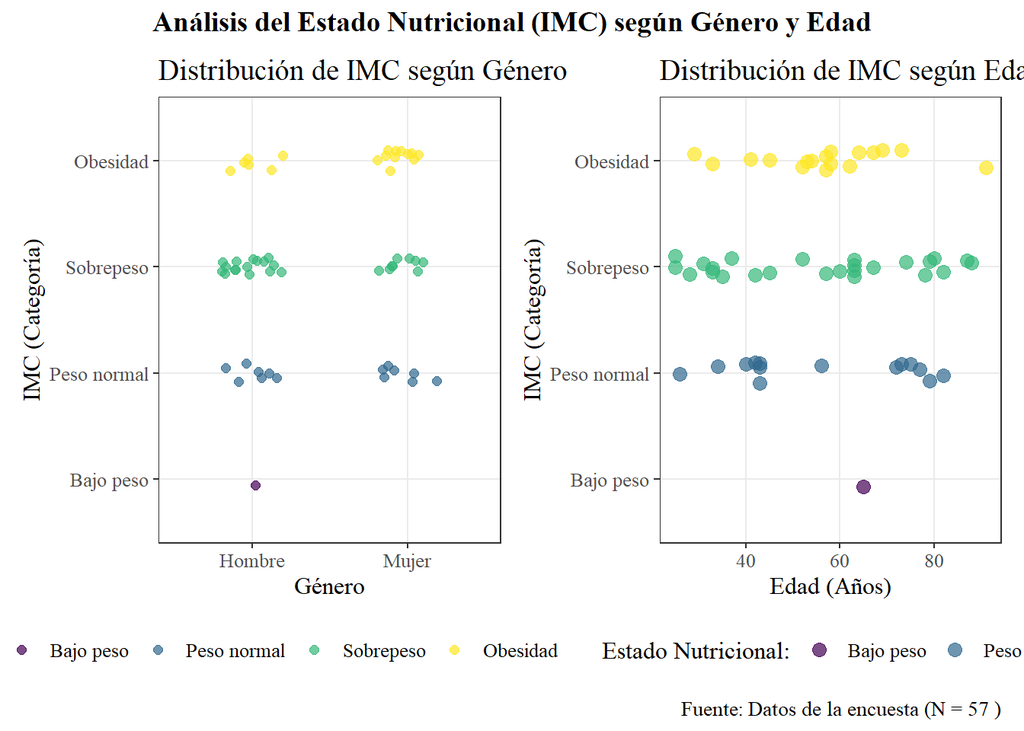

```r
# --- MOSTRAR RESULTADOS ---
grafico_final <- (p1 | p2) +
  plot_layout(guides = "collect") &
  theme(legend.position = "bottom")

# Agregar un título global (opcional)
grafico_final <- grafico_final + plot_annotation(
  title = "Análisis del Estado Nutricional (IMC) según Género y Edad",
  # Se agrega el argumento caption con tu texto dinámico
  caption = paste("Fuente: Datos de la encuesta (N =", stats_edad$n, ")"),
  theme = theme(
    plot.title = element_text(family = "serif", size = 14, face = "bold", hjust = 0.5),
    # Aseguramos que la fuente aparezca a la derecha (hjust = 1) y con la misma familia de fuente
    plot.caption = element_text(family = "serif", size = 10, hjust = 1)
  )
)
grafico_final
```

El examen de las variables antropométricas y demográficas permite establecer las siguientes inferencias respecto al estado nutricional de la muestra:

**1. Dimorfismo en la distribución del IMC según género** Se identifica una diferenciación estructural significativa en el estado nutricional condicionada por el género. En **la población masculina, predomina la categoría de Sobrepeso**, la cual agrupa a más de la mitad de los sujetos evaluados. Por el contrario, en la **población femenina se observa una tendencia marcada hacia la Obesidad (aproximadamente el 40% de la submuestra)**, constituyéndose como la categoría prevalente en mujeres, en contraste con su menor frecuencia en el grupo masculino.

**2. Transversalidad del riesgo metabólico según edad**. El análisis bivariado entre edad e IMC demuestra la ausencia de una correlación lineal directa. **La malnutrición por exceso (Sobrepeso y Obesidad) se manifiesta de manera transversal a lo largo de todo el ciclo vital adulto, sin restringirse a grupos etarios específicos.**

Se detectaron categorías de alto riesgo tanto en adultos jóvenes (20-30 años) como en adultos mayores (+70 años). Esto podría sugerir que, en la muestra estudiada, la edad cronológica no actúa por sí sola como un factor protector ni agravante determinante, evidenciando una dispersión generalizada del riesgo metabólico.

### Consumo de tabaco

La evidencia científica actual, respaldada por la Agencia Internacional para la Investigación del Cáncer (IARC), ha reclasificado al **tabaquismo como un factor de riesgo causal directo para el cáncer colorrectal (CCR)**.

**Múltiples metaanálisis han demostrado que el tabaquismo activo incrementa significativamente tanto la incidencia como la mortalidad por CCR, mostrando una clara relación dosis-respuesta** (Botteri et al., JAMA, 2008; IARC, 2012).

El consumo de tabaco actúa como un agente cancerígeno sistémico. A diferencia del contacto directo en el pulmón, en el colon el daño es mediado por la absorción circulatoria de cancerígenos del humo, como las nitrosaminas, aminas aromáticas heterocíclicas e hidrocarburos policíclicos aromáticos, que alcanzan la mucosa colónica a través del torrente sanguíneo o mediante la ingestión de saliva contaminada (Li et al., Gastroenterology, 2014).

Por esto, en el análisis se ha incorporado la variable de hábito de tabaquismo (ccr_h_tabac) para segmentar la muestra según el nivel de exposición acumulada a estos agentes cancerígenos. La clasificación utilizada en el conjunto de datos distingue entre las siguientes categorías de riesgo:

Fumo actualmente: Máxima exposición activa y riesgo continuado.

Fumé en el pasado: Riesgo latente, dado que el daño genético puede persistir años tras el cese.

Nunca fumé: Grupo de referencia basal.

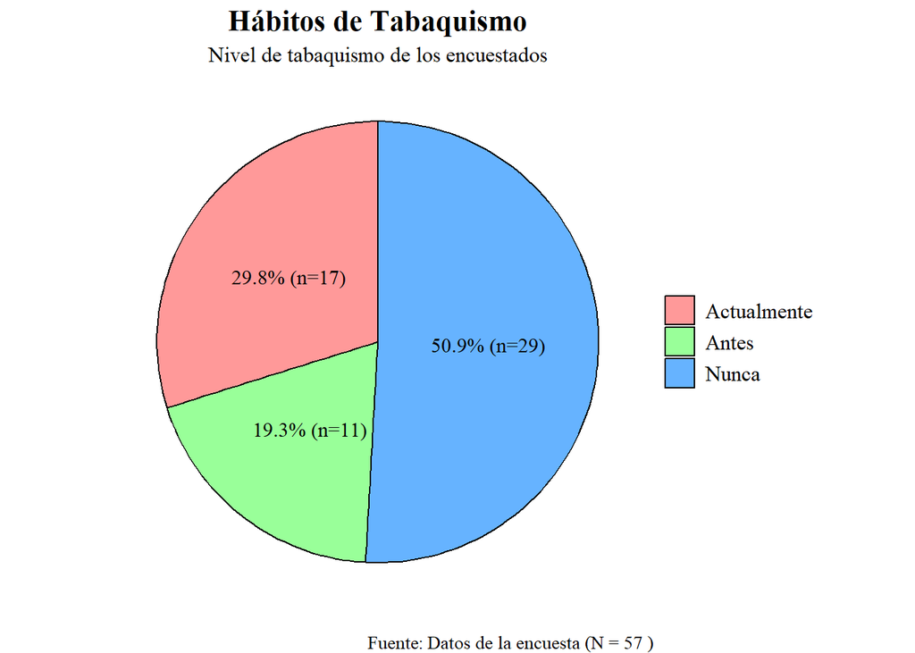

```r
data_tabaco <- data_a_ccr %>%
  mutate(
    # Convertimos a caracter por seguridad
    ccr_h_tabac = as.character(ccr_h_tabac),

    # Lógica de reemplazo usando búsqueda parcial (grepl)
    # Esto atrapa tanto "Fumé" bien escrito como "FumÃ©" mal escrito.
    ccr_h_tabac_clean = case_when(
      # Si dice "Nunca" (ej. "Nunca fumé", "Nunca FumÃ©") -> "Nunca"
      grepl("Nunca", ccr_h_tabac, ignore.case = TRUE) ~ "Nunca",

      # Si dice "pasado" (ej. "Fumé en el pasado") -> "Antes"
      grepl("pasado", ccr_h_tabac, ignore.case = TRUE) ~ "Antes",

      # Si dice "actualmente" (ej. "Fumo actualmente") -> "Actualmente"
      grepl("actualmente", ccr_h_tabac, ignore.case = TRUE) ~ "Actualmente",

      # Si no coincide con nada, mantenemos el original para verificar errores
      TRUE ~ ccr_h_tabac
    )
  )

# ==============================================================================
# 4. PREPARACIÓN DE DATOS PARA EL GRÁFICO
# ==============================================================================
datos_grafico <- data_tabaco %>%
  # Filtramos vacíos o NAs que no se pudieron clasificar
  filter(!is.na(ccr_h_tabac_clean) & ccr_h_tabac_clean %in% c("Nunca", "Antes", "Actualmente")) %>%
  count(ccr_h_tabac_clean) %>%
  mutate(
    porcentaje = n / sum(n),
    etiqueta = percent(porcentaje, accuracy = 0.1)
  )

# ==============================================================================
# 5. DEFINICIÓN DE COLORES (Asignados a los NUEVOS nombres)
# ==============================================================================
colores_personalizados <- c(
  "Actualmente" = "#ff9999",  # Rojo suave
  "Nunca"       = "#66b3ff",  # Azul suave
  "Antes"       = "#99ff99"   # Verde suave
)

# ==============================================================================
# 6. GENERACIÓN DEL GRÁFICO
# ==============================================================================
datos_grafico <- data_tabaco %>%
  # Aseguramos de filtrar NAs y categorías vacías
  filter(!is.na(ccr_h_tabac_clean) & ccr_h_tabac_clean %in% c("Nunca", "Antes", "Actualmente")) %>%
  count(ccr_h_tabac_clean) %>%
  mutate(
    porcentaje = n / sum(n),
    # AQUÍ ESTÁ EL CAMBIO: Concatenamos porcentaje y n
    etiqueta = paste0(percent(porcentaje, accuracy = 0.1), " (n=", n, ")")
  )

# Calculamos el N total para usarlo en el título/caption dinámicamente
total_encuestados <- sum(datos_grafico$n)

# 2. GENERACIÓN DEL GRÁFICO
ggplot(datos_grafico, aes(x = "", y = porcentaje, fill = ccr_h_tabac_clean)) +
  # Usamos linewidth para bordes nítidos
  geom_bar(stat = "identity", width = 1, color = "black", linewidth = 0.5) +

  # Convertimos a gráfico circular
  coord_polar("y", start = 0) +

  # Aplicamos los colores
  scale_fill_manual(values = colores_personalizados) +

  # Etiquetas de porcentaje + absoluto
  geom_text(aes(label = etiqueta),
            position = position_stack(vjust = 0.5),
            color = "black",
            family = "serif",
            size = 4) + # Puedes bajar a 4 si el texto es muy largo

  # Estilo académico
  theme_void() +
  theme(
    text = element_text(family = "serif"),
    plot.title = element_text(hjust = 0.5, size = 16, face = "bold"),
    plot.subtitle = element_text(hjust = 0.5, size = 12),
    plot.caption = element_text(hjust = 1, size = 10, margin = margin(t = 10)), # Margen extra para el caption
    legend.title = element_blank(),
    legend.text = element_text(size = 12),
    legend.position = "right"
  ) +

  # Títulos dinámicos
  labs(title = "Hábitos de Tabaquismo",
       subtitle = "Nivel de tabaquismo de los encuestados",
       # Usamos la variable 'total_encuestados' que calculamos arriba para que sea automático
       caption = paste("Fuente: Datos de la encuesta (N =", total_encuestados, ")")
  )
```

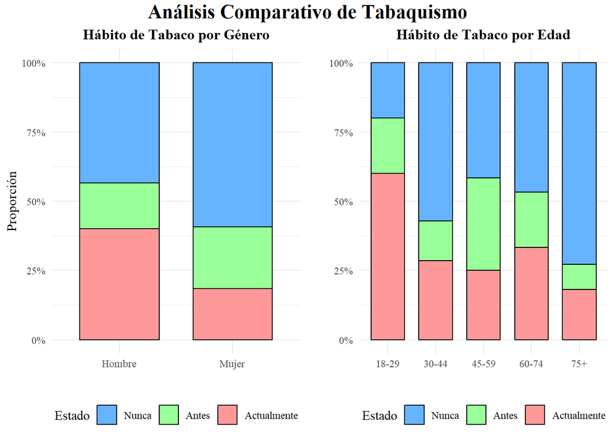

```r
library(scales)
library(grid)
library(kableExtra)

data_tabaco_analisis <- data %>%
  mutate(
    # 1. Limpieza de Tabaquismo (Tu lógica original mejorada con factores)
    ccr_h_tabac = as.character(ccr_h_tabac),
    ccr_h_tabac_clean = case_when(
      grepl("Nunca", ccr_h_tabac, ignore.case = TRUE) ~ "Nunca",
      grepl("pasado", ccr_h_tabac, ignore.case = TRUE) ~ "Antes",
      grepl("actualmente", ccr_h_tabac, ignore.case = TRUE) ~ "Actualmente",
      TRUE ~ NA_character_ # Convertimos no coincidentes a NA para limpiar
    ),
    # Convertimos a Factor para forzar el orden lógico en el gráfico
    ccr_h_tabac_clean = factor(ccr_h_tabac_clean,
                               levels = c("Nunca", "Antes", "Actualmente")),

    # 2. Creación de Grupos Etarios (Binning)
    # Analizamos la distribución: min 25, max 91. Creamos cortes estándar.
    grupo_etario = cut(edad,
                       breaks = c(-Inf, 29, 44, 59, 74, Inf),
                       labels = c("18-29", "30-44", "45-59", "60-74", "75+")),

    # 3. Normalización de Género y Educación (si es necesario)
    genero = factor(genero),
    ccr_s_educ = factor(ccr_s_educ)
  ) %>%
  # Filtramos registros que no tengan clasificación de tabaco válida
  filter(!is.na(ccr_h_tabac_clean))

# ==============================================================================
# 2. DEFINICIÓN DE ESTILOS Y COLORES
# ==============================================================================
colores_personalizados <- c(
  "Actualmente" = "#ff9999",  # Rojo suave
  "Nunca"       = "#66b3ff",  # Azul suave
  "Antes"       = "#99ff99"   # Verde suave
)

# Tema base para evitar repetición de código
theme_custom <- theme_minimal() +
  theme(
    text = element_text(family = "serif"),
    legend.position = "bottom",
    plot.title = element_text(face = "bold", size = 12, hjust = 0.5),
    axis.text.x = element_text(angle = 0, hjust = 0.5)
  )

# ==============================================================================
# 3. CREACIÓN DE GRÁFICOS
# ==============================================================================

# --- Gráfico A: Tabaquismo por Género ---
p1 <- ggplot(data_tabaco_analisis, aes(x = genero, fill = ccr_h_tabac_clean)) +
  geom_bar(position = "fill", color = "black", width = 0.7) +
  scale_y_continuous(labels = scales::percent) +
  scale_fill_manual(values = colores_personalizados) +
  labs(title = "Hábito de Tabaco por Género",
       y = "Proporción", x = "", fill = "Estado") +
  theme_custom

# --- Gráfico B: Tabaquismo por Grupo Etario ---
p2 <- ggplot(data_tabaco_analisis, aes(x = grupo_etario, fill = ccr_h_tabac_clean)) +
  geom_bar(position = "fill", color = "black", width = 0.7) +
  scale_y_continuous(labels = scales::percent) +
  scale_fill_manual(values = colores_personalizados) +
  labs(title = "Hábito de Tabaco por Edad",
       y = "", x = "", fill = "Estado") +
  theme_custom

# ==============================================================================
# 4. DISPOSICIÓN EN GRILLA (1 Fila x 2 Columnas)
# ==============================================================================
grid.arrange(p1, p2, ncol = 2,
             top = textGrob("Análisis Comparativo de Tabaquismo",
                            gp = gpar(fontsize = 16, fontfamily = "serif", fontface = "bold")))
```

```r
# Función auxiliar para crear la tabla dinámica
crear_tabla_resumen <- function(data, variable_agrupacion, nombre_columna, titulo_tabla) {

  # 1. Crear tabla cruzada con conteos (Lógica original)
  tabla_base <- data %>%
    count({{variable_agrupacion}}, ccr_h_tabac_clean) %>%
    group_by({{variable_agrupacion}}) %>%
    mutate(prop = n / sum(n)) %>%
    ungroup() %>%
    mutate(valor = paste0(n, " (", percent(prop, accuracy = 0.1), ")")) %>%
    select({{variable_agrupacion}}, ccr_h_tabac_clean, valor) %>%
    pivot_wider(names_from = ccr_h_tabac_clean, values_from = valor, values_fill = "0 (0.0%)")

  # 2. Calcular fila de TOTAL GENERAL
  total_gral <- data %>%
    count(ccr_h_tabac_clean) %>%
    mutate(prop = n / sum(n)) %>%
    mutate(valor = paste0(n, " (", percent(prop, accuracy = 0.1), ")")) %>%
    select(ccr_h_tabac_clean, valor) %>%
    pivot_wider(names_from = ccr_h_tabac_clean, values_from = valor) %>%
    mutate({{variable_agrupacion}} := "TOTAL")

  # Unimos
  tabla_final <- bind_rows(tabla_base, total_gral)
  colnames(tabla_final)[1] <- nombre_columna

  # 3. Renderizado Kable con Fuente
  tabla_kable <- kable(tabla_final,
                       caption = titulo_tabla,
                       align = paste0("l", strrep("c", ncol(tabla_final)-1)),
                       booktabs = TRUE) %>%
    kable_styling(full_width = FALSE, position = "left", bootstrap_options = c("striped", "hover")) %>%
    row_spec(0, bold = TRUE, color = "white", background = "#444444") %>%
    row_spec(nrow(tabla_final), bold = TRUE, background = "#f5f5f5") %>%

    # --- AQUÍ AGREGAMOS LA FUENTE ---
    footnote(general = "Fuente: Datos de la encuesta (N=57)",
             general_title = "",        # Eliminamos el prefijo "Note:" por defecto
             footnote_as_chunk = TRUE)  # Mantiene el formato limpio

  return(tabla_kable)
}
# --- Generación de las 3 Tablas Solicitadas ---

# Tabla 1: Por Grupo Etario
tabla_edad <- crear_tabla_resumen(data_tabaco_analisis, grupo_etario, "Grupo Etario",
                                  "Tabla 7: Distribución de Tabaquismo por Edad")

# Tabla 2: Por Género
tabla_genero <- crear_tabla_resumen(data_tabaco_analisis, genero, "Género",
                                    "Tabla 8: Distribución de Tabaquismo por Género")

# Tabla 3: Por Nivel Educacional
tabla_educ <- crear_tabla_resumen(data_tabaco_analisis, ccr_s_educ, "Nivel Educacional",
                                  "Tabla 9: Distribución de Tabaquismo por Educación")

# Imprimir las tablas
tabla_edad
```

Tabla 7: Distribución de Tabaquismo por Edad

| Grupo Etario | Nunca | Antes | Actualmente |
| --- | --- | --- | --- |
| 18-29 | 1 (20.0%) | 1 (20.0%) | 3 (60.0%) |
| 30-44 | 8 (57.1%) | 2 (14.3%) | 4 (28.6%) |
| 45-59 | 5 (41.7%) | 4 (33.3%) | 3 (25.0%) |
| 60-74 | 7 (46.7%) | 3 (20.0%) | 5 (33.3%) |
| 75+ | 8 (72.7%) | 1 (9.1%) | 2 (18.2%) |
| TOTAL | 29 (50.9%) | 11 (19.3%) | 17 (29.8%) |

Fuente: Datos de la encuesta (N=57)

```r
tabla_genero
```

Tabla 8: Distribución de Tabaquismo por Género

| Género | Nunca | Antes | Actualmente |
| --- | --- | --- | --- |
| Hombre | 13 (43.3%) | 5 (16.7%) | 12 (40.0%) |
| Mujer | 16 (59.3%) | 6 (22.2%) | 5 (18.5%) |
| TOTAL | 29 (50.9%) | 11 (19.3%) | 17 (29.8%) |

Fuente: Datos de la encuesta (N=57)

```r
tabla_educ
```

Tabla 9: Distribución de Tabaquismo por Educación

| Nivel Educacional | Nunca | Antes | Actualmente |
| --- | --- | --- | --- |
| Básico (completo/incompleto) | 6 (50.0%) | 1 (8.3%) | 5 (41.7%) |
| Media (completo/incompleto) | 15 (62.5%) | 5 (20.8%) | 4 (16.7%) |
| Sin escolaridad | 0 (0.0%) | 0 (0.0%) | 1 (100.0%) |
| Superior (completo/incompleto) | 8 (40.0%) | 5 (25.0%) | 7 (35.0%) |
| TOTAL | 29 (50.9%) | 11 (19.3%) | 17 (29.8%) |

Fuente: Datos de la encuesta (N=57)

### Consumo de alcohol

La evidencia científica actual, respaldada por la Agencia Internacional para la Investigación del Cáncer (IARC), ha clasificado al **consumo de bebidas alcohólicas como un carcinógeno del Grupo 1, confirmándolo como un factor de riesgo causal directo para el cáncer colorrectal (CCR)**.

Múltiples metaanálisis han demostrado que **la ingesta de alcohol incrementa significativamente el riesgo relativo de desarrollar CCR**, evidenciando una asociación positiva tanto en hombres como en mujeres y mostrando una clara relación dosis-respuesta, donde el riesgo aumenta proporcionalmente con la cantidad diaria consumida (Fedirko et al., Annals of Oncology, 2011; Bagnardi et al., British Journal of Cancer, 2015).

El consumo de alcohol actúa a través de mecanismos metabólicos y genotóxicos complejos. El daño principal es mediado por el acetaldehído (el principal metabolito del etanol), que interfiere con la síntesis y reparación del ADN. Además, el alcohol actúa como solvente facilitando la absorción de otros carcinógenos en la mucosa, induce estrés oxidativo y puede provocar deficiencia de folatos, alterando la metilación del ADN necesaria para la estabilidad genética (Boffetta & Hashibe, Lancet Oncol, 2006).

Ninguno: Grupo de referencia basal o abstemio, libre de la exposición al agente.

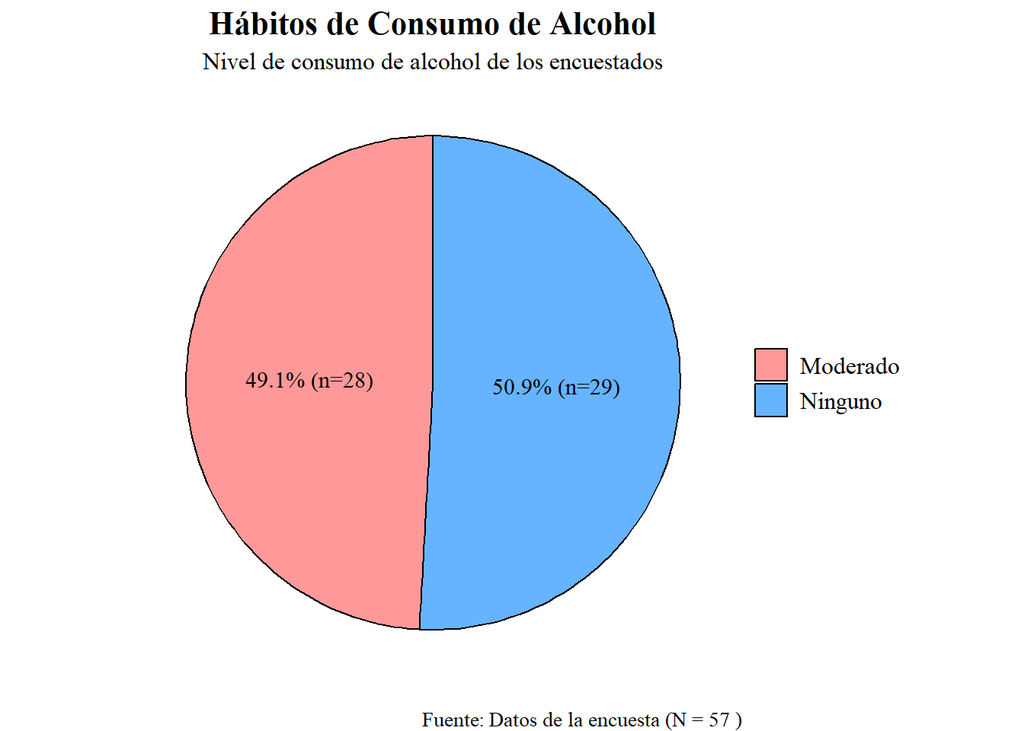

```r
# ==============================================================================
# 1. PREPARACIÓN DE DATOS (Adaptado para Alcohol)
# ==============================================================================
data_alcohol <- data %>%
  mutate(
    # Convertimos a caracter por seguridad
    ccr_h_alc = as.character(ccr_h_alc),

    # Lógica de reemplazo y limpieza
    ccr_h_alc_clean = case_when(
      # Mapeamos "Ninguno" a "Ninguno" (Equivalente al azul de 'Nunca')
      grepl("Ninguno", ccr_h_alc, ignore.case = TRUE) ~ "Ninguno",

      # Mapeamos "Moderado" a "Moderado" (Equivalente al rojo de 'Actualmente')
      grepl("Moderado", ccr_h_alc, ignore.case = TRUE) ~ "Moderado",

      # Caso por defecto
      TRUE ~ ccr_h_alc
    )
  )

# ==============================================================================
# 2. DEFINICIÓN DE COLORES
# ==============================================================================
# Mantenemos la paleta: Azul para no consumo, Rojo para consumo activo
colores_alcohol <- c(
  "Moderado" = "#ff9999",  # Rojo suave
  "Ninguno"  = "#66b3ff"   # Azul suave
)

# ==============================================================================
# 3. GENERACIÓN DEL GRÁFICO
# ==============================================================================
datos_grafico_alc <- data_alcohol %>%
  filter(!is.na(ccr_h_alc_clean) & ccr_h_alc_clean %in% c("Ninguno", "Moderado")) %>%
  count(ccr_h_alc_clean) %>%
  mutate(
    porcentaje = n / sum(n),
    etiqueta = paste0(percent(porcentaje, accuracy = 0.1), " (n=", n, ")")
  )

total_encuestados_alc <- sum(datos_grafico_alc$n)

ggplot(datos_grafico_alc, aes(x = "", y = porcentaje, fill = ccr_h_alc_clean)) +
  geom_bar(stat = "identity", width = 1, color = "black", linewidth = 0.5) +
  coord_polar("y", start = 0) +
  scale_fill_manual(values = colores_alcohol) +
  geom_text(aes(label = etiqueta),
            position = position_stack(vjust = 0.5),
            color = "black",
            family = "serif",
            size = 4) +
  theme_void() +
  theme(
    text = element_text(family = "serif"),
    plot.title = element_text(hjust = 0.5, size = 16, face = "bold"),
    plot.subtitle = element_text(hjust = 0.5, size = 12),
    plot.caption = element_text(hjust = 1, size = 10, margin = margin(t = 10)),
    legend.title = element_blank(),
    legend.text = element_text(size = 12),
    legend.position = "right"
  ) +
  labs(title = "Hábitos de Consumo de Alcohol",
       subtitle = "Nivel de consumo de alcohol de los encuestados",
       caption = paste("Fuente: Datos de la encuesta (N =", total_encuestados_alc, ")")
  )
```

```r
library(tidyverse)
library(scales)
library(kableExtra)
library(gridExtra)
library(grid)

# ==============================================================================
# 1. PREPARACIÓN DE DATOS (ALCOHOL)
# ==============================================================================
# Asumimos que 'data' es tu dataframe original cargado
data_alcohol_analisis <- data %>%
  mutate(
    # --- Limpieza Variable Alcohol ---
    ccr_h_alc = as.character(ccr_h_alc),
    ccr_h_alc_clean = case_when(
      grepl("Ninguno", ccr_h_alc, ignore.case = TRUE) ~ "Ninguno",
      grepl("Moderado", ccr_h_alc, ignore.case = TRUE) ~ "Moderado",
      TRUE ~ NA_character_
    ),
    # Factor ordenado: Primero "Ninguno" (Base), luego "Moderado"
    ccr_h_alc_clean = factor(ccr_h_alc_clean, levels = c("Ninguno", "Moderado")),

    # --- Variables de Agrupación (Edad, Género, Educación) ---
    grupo_etario = cut(edad,
                       breaks = c(-Inf, 29, 44, 59, 74, Inf),
                       labels = c("18-29", "30-44", "45-59", "60-74", "75+")),
    genero = factor(genero),
    ccr_s_educ = factor(ccr_s_educ)
  ) %>%
  # Filtramos NAs de la variable de interés
  filter(!is.na(ccr_h_alc_clean))

# Definimos el N total "indexado" como solicitaste
n_total_encuesta <- 57
```

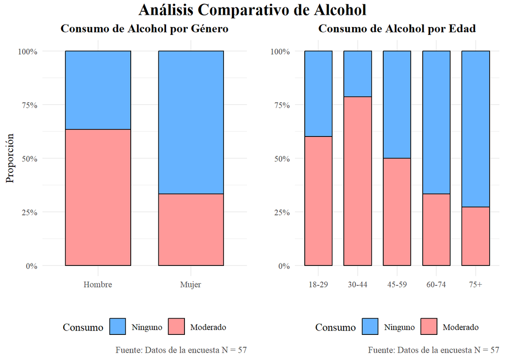

```r
# ==============================================================================
# 2. GRÁFICOS COMPARATIVOS (GRILLA)
# ==============================================================================

# Definición de Colores (Consistente con tu código previo)
colores_alcohol <- c("Moderado" = "#ff9999", "Ninguno" = "#66b3ff")

# Tema común
theme_custom <- theme_minimal() +
  theme(
    text = element_text(family = "serif"),
    legend.position = "bottom",
    plot.title = element_text(face = "bold", size = 12, hjust = 0.5),
    plot.caption = element_text(size = 9, color = "gray30"),
    axis.text.x = element_text(angle = 0, hjust = 0.5)
  )

# --- Gráfico 1: Alcohol por Género ---
p_alc_gen <- ggplot(data_alcohol_analisis, aes(x = genero, fill = ccr_h_alc_clean)) +
  geom_bar(position = "fill", color = "black", width = 0.7) +
  scale_y_continuous(labels = scales::percent) +
  scale_fill_manual(values = colores_alcohol) +
  labs(title = "Consumo de Alcohol por Género",
       y = "Proporción", x = "", fill = "Consumo",
       caption = paste("Fuente: Datos de la encuesta N =", n_total_encuesta)) +
  theme_custom

# --- Gráfico 2: Alcohol por Grupo Etario ---
p_alc_edad <- ggplot(data_alcohol_analisis, aes(x = grupo_etario, fill = ccr_h_alc_clean)) +
  geom_bar(position = "fill", color = "black", width = 0.7) +
  scale_y_continuous(labels = scales::percent) +
  scale_fill_manual(values = colores_alcohol) +
  labs(title = "Consumo de Alcohol por Edad",
       y = "", x = "", fill = "Consumo",
       caption = paste("Fuente: Datos de la encuesta N =", n_total_encuesta)) +
  theme_custom

# --- Renderizado de la Grilla (1x2) ---
grid.arrange(p_alc_gen, p_alc_edad, ncol = 2,
             top = textGrob("Análisis Comparativo de Alcohol",
                            gp = gpar(fontsize = 16, fontfamily = "serif", fontface = "bold")))
```

```r
# ==============================================================================
# 3. TABLAS RESUMEN (ESTILO KABLE)
# ==============================================================================

# Función adaptada para contar la variable 'ccr_h_alc_clean'
crear_tabla_alcohol <- function(data, variable_agrupacion, nombre_columna, titulo_tabla) {

  # 1. Cuerpo de la tabla
  tabla_base <- data %>%
    count({{variable_agrupacion}}, ccr_h_alc_clean) %>%
    group_by({{variable_agrupacion}}) %>%
    mutate(prop = n / sum(n)) %>%
    ungroup() %>%
    mutate(valor = paste0(n, " (", percent(prop, accuracy = 0.1), ")")) %>%
    select({{variable_agrupacion}}, ccr_h_alc_clean, valor) %>%
    pivot_wider(names_from = ccr_h_alc_clean, values_from = valor, values_fill = "0 (0.0%)")

  # 2. Fila Total
  total_gral <- data %>%
    count(ccr_h_alc_clean) %>%
    mutate(prop = n / sum(n)) %>%
    mutate(valor = paste0(n, " (", percent(prop, accuracy = 0.1), ")")) %>%
    select(ccr_h_alc_clean, valor) %>%
    pivot_wider(names_from = ccr_h_alc_clean, values_from = valor) %>%
    mutate({{variable_agrupacion}} := "TOTAL")

  # 3. Unión y Renderizado
  tabla_final <- bind_rows(tabla_base, total_gral)
  colnames(tabla_final)[1] <- nombre_columna

  kable(tabla_final,
        caption = titulo_tabla,
        align = paste0("l", strrep("c", ncol(tabla_final)-1)),
        booktabs = TRUE) %>%
    kable_styling(full_width = FALSE, position = "left", bootstrap_options = c("striped", "hover")) %>%
    row_spec(0, bold = TRUE, color = "white", background = "#444444") %>%
    row_spec(nrow(tabla_final), bold = TRUE, background = "#f5f5f5") %>%
    # Fuente indexada con código
    footnote(general = paste("Fuente: Datos de la encuesta N =", n_total_encuesta),
             general_title = "",
             footnote_as_chunk = TRUE)
}

# --- Generación de las Tablas ---

# Tabla A: Por Grupo Etario
tabla_alc_edad <- crear_tabla_alcohol(data_alcohol_analisis, grupo_etario, "Grupo Etario",
                                      "Tabla 10: Consumo de Alcohol por Edad")

# Tabla B: Por Género
tabla_alc_genero <- crear_tabla_alcohol(data_alcohol_analisis, genero, "Género",
                                        "Tabla 11: Consumo de Alcohol por Género")

# Tabla C: Por Nivel Educacional
tabla_alc_educ <- crear_tabla_alcohol(data_alcohol_analisis, ccr_s_educ, "Nivel Educacional",
                                      "Tabla 12: Consumo de Alcohol por Educación")

# Imprimir resultados
tabla_alc_edad
```

Tabla 10: Consumo de Alcohol por Edad

| Grupo Etario | Ninguno | Moderado |
| --- | --- | --- |
| 18-29 | 2 (40.0%) | 3 (60.0%) |
| 30-44 | 3 (21.4%) | 11 (78.6%) |
| 45-59 | 6 (50.0%) | 6 (50.0%) |
| 60-74 | 10 (66.7%) | 5 (33.3%) |
| 75+ | 8 (72.7%) | 3 (27.3%) |
| TOTAL | 29 (50.9%) | 28 (49.1%) |

Fuente: Datos de la encuesta N = 57

```r
tabla_alc_genero
```

Tabla 11: Consumo de Alcohol por Género

| Género | Ninguno | Moderado |
| --- | --- | --- |
| Hombre | 11 (36.7%) | 19 (63.3%) |
| Mujer | 18 (66.7%) | 9 (33.3%) |
| TOTAL | 29 (50.9%) | 28 (49.1%) |

Fuente: Datos de la encuesta N = 57

```r
tabla_alc_educ
```

Tabla 12: Consumo de Alcohol por Educación

| Nivel Educacional | Ninguno | Moderado |
| --- | --- | --- |
| Básico (completo/incompleto) | 6 (50.0%) | 6 (50.0%) |
| Media (completo/incompleto) | 14 (58.3%) | 10 (41.7%) |
| Sin escolaridad | 1 (100.0%) | 0 (0.0%) |
| Superior (completo/incompleto) | 8 (40.0%) | 12 (60.0%) |
| TOTAL | 29 (50.9%) | 28 (49.1%) |

Fuente: Datos de la encuesta N = 57

### Consumo de drogas

La evidencia científica ha comenzado a identificar **el consumo de sustancias ilícitas como un factor de riesgo relevante en la oncología digestiva, asociando los Trastornos por Consumo de Sustancias (TCS) con un peor pronóstico y una mayor carga de mortalidad en el cáncer colorrectal (CCR)**.

Investigaciones recientes han sugerido que **el consumo problemático de sustancias, particularmente de cannabis y opioides, se correlaciona con resultados clínicos adversos**. Un estudio publicado en Annals of Epidemiology indicó que los pacientes con historial de consumo de sustancias presentan un riesgo de mortalidad significativamente elevado, sugiriendo una interacción biológica compleja más allá de las barreras conductuales (Cuomo et al., Annals of Epidemiology, 2025).

El consumo prolongado de opioides y cannabinoides ha sido vinculado a la alteración de la motilidad gastrointestinal y a la disbiosis del microbioma intestinal, creando un microambiente pro-inflamatorio que favorece la carcinogénesis. Además, muchas drogas ilícitas contienen agentes de corte tóxicos (como la fenacetina) o son consumidas vía inhalatoria, introduciendo hidrocarburos policíclicos y estrés oxidativo sistémico similar al del tabaco, lo que compromete la vigilancia inmunológica antitumoral (Liang et al., Frontiers in Oncology, 2022).

Por esto, **en el análisis se ha incorporado la variable de consumo de drogas (ccr_h_drogas) para segmentar la muestra según la presencia de este factor de comorbilidad complejo**. La clasificación utilizada en el conjunto de datos distingue entre las siguientes categorías de riesgo:

Sí: Presencia de consumo activo o historial declarado.

No: Grupo de referencia sin exposición declarada a sustancias ilícitas.

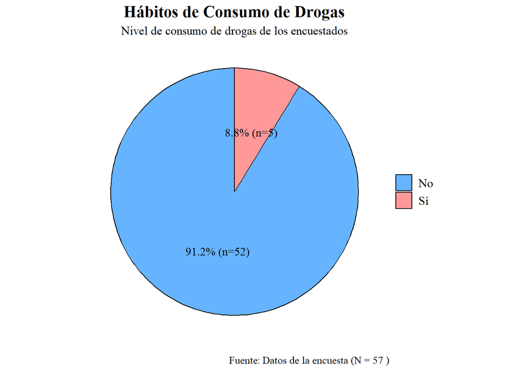

```r
# ==============================================================================
# 1. PREPARACIÓN DE DATOS (Adaptado para Drogas)
# ==============================================================================
data_drogas <- data %>%
  mutate(
    # Convertimos a caracter por seguridad
    ccr_h_drogas = as.character(ccr_h_drogas),

    # Lógica de reemplazo simple dado que los datos son binarios
    ccr_h_drogas_clean = case_when(
      # Detectamos variaciones de "Sí" (con o sin tilde)
      grepl("S[íi]", ccr_h_drogas, ignore.case = TRUE) ~ "Sí",

      # Detectamos "No"
      grepl("No", ccr_h_drogas, ignore.case = TRUE) ~ "No",

      # Mantenemos original si no coincide (para control de calidad)
      TRUE ~ ccr_h_drogas
    )
  )

# ==============================================================================
# 2. DEFINICIÓN DE COLORES
# ==============================================================================
colores_drogas <- c(
  "Sí" = "#ff9999",  # Rojo suave (Alerta/Positivo)
  "No" = "#66b3ff"   # Azul suave (Negativo/Control)
)

# ==============================================================================
# 3. GENERACIÓN DEL GRÁFICO
# ==============================================================================
datos_grafico_drogas <- data_drogas %>%
  # Filtramos solo las categorías de interés
  filter(!is.na(ccr_h_drogas_clean) & ccr_h_drogas_clean %in% c("No", "Sí")) %>%
  count(ccr_h_drogas_clean) %>%
  mutate(
    porcentaje = n / sum(n),
    # Etiqueta con porcentaje y número absoluto
    etiqueta = paste0(percent(porcentaje, accuracy = 0.1), " (n=", n, ")")
  )

# Calculamos N total para el caption
total_encuestados_drogas <- sum(datos_grafico_drogas$n)

ggplot(datos_grafico_drogas, aes(x = "", y = porcentaje, fill = ccr_h_drogas_clean)) +
  geom_bar(stat = "identity", width = 1, color = "black", linewidth = 0.5) +
  coord_polar("y", start = 0) +
  scale_fill_manual(values = colores_drogas) +
  geom_text(aes(label = etiqueta),
            position = position_stack(vjust = 0.5),
            color = "black",
            family = "serif",
            size = 4) +
  theme_void() +
  theme(
    text = element_text(family = "serif"),
    plot.title = element_text(hjust = 0.5, size = 16, face = "bold"),
    plot.subtitle = element_text(hjust = 0.5, size = 12),
    plot.caption = element_text(hjust = 1, size = 10, margin = margin(t = 10)),
    legend.title = element_blank(),
    legend.text = element_text(size = 12),
    legend.position = "right"
  ) +
  labs(title = "Hábitos de Consumo de Drogas",
       subtitle = "Nivel de consumo de drogas de los encuestados",
       caption = paste("Fuente: Datos de la encuesta (N =", total_encuestados_drogas, ")")
  )
```

En el análisis de los datos de la encuesta se aprecia una **baja prevalencia en el consumo de drogas ilícitas**.

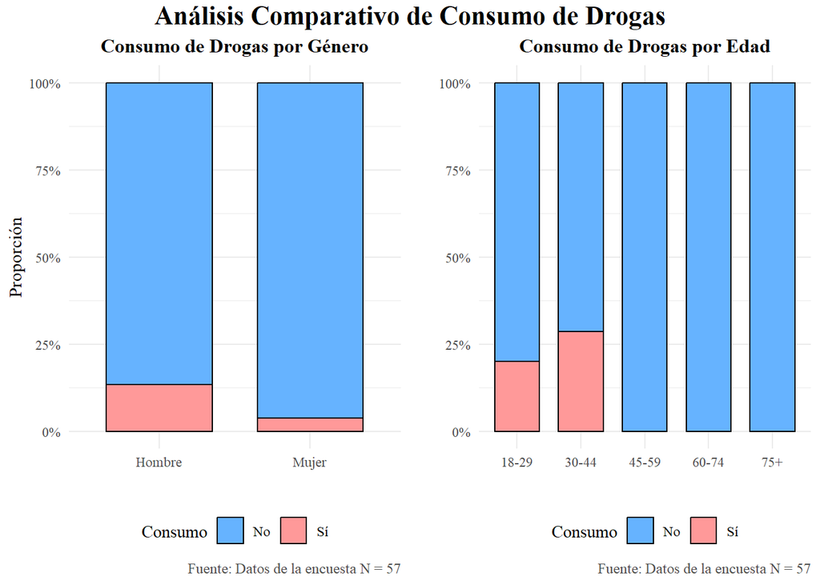

```r
library(tidyverse)
library(scales)
library(kableExtra)
library(gridExtra)
library(grid)

# ==============================================================================
# 1. PREPARACIÓN DE DATOS (DROGAS)
# ==============================================================================
# Asumimos que 'data' es tu dataframe original cargado
data_drogas_analisis <- data %>%
  mutate(
    # --- Limpieza Variable Drogas ---
    ccr_h_drogas = as.character(ccr_h_drogas),
    ccr_h_drogas_clean = case_when(
      # Detectamos "No"
      grepl("No", ccr_h_drogas, ignore.case = TRUE) ~ "No",
      # Detectamos "Si" o "Sí" (con o sin tilde)
      grepl("S[íi]", ccr_h_drogas, ignore.case = TRUE) ~ "Sí",
      TRUE ~ NA_character_
    ),
    # Factor ordenado: Primero "No" (Base), luego "Sí" (Riesgo)
    ccr_h_drogas_clean = factor(ccr_h_drogas_clean, levels = c("No", "Sí")),

    # --- Variables de Agrupación (Edad, Género, Educación) ---
    grupo_etario = cut(edad,
                       breaks = c(-Inf, 29, 44, 59, 74, Inf),
                       labels = c("18-29", "30-44", "45-59", "60-74", "75+")),
    genero = factor(genero),
    ccr_s_educ = factor(ccr_s_educ)
  ) %>%
  # Filtramos NAs de la variable de interés
  filter(!is.na(ccr_h_drogas_clean))

# Definimos el N total "indexado"
n_total_encuesta <- 57

# ==============================================================================
# 2. GRÁFICOS COMPARATIVOS (GRILLA)
# ==============================================================================

# Definición de Colores
# Rojo para "Sí" (Riesgo), Azul para "No" (Seguro)
colores_drogas <- c("Sí" = "#ff9999", "No" = "#66b3ff")

# Tema común
theme_custom <- theme_minimal() +
  theme(
    text = element_text(family = "serif"),
    legend.position = "bottom",
    plot.title = element_text(face = "bold", size = 12, hjust = 0.5),
    plot.caption = element_text(size = 9, color = "gray30"),
    axis.text.x = element_text(angle = 0, hjust = 0.5)
  )

# --- Gráfico 1: Drogas por Género ---
p_drogas_gen <- ggplot(data_drogas_analisis, aes(x = genero, fill = ccr_h_drogas_clean)) +
  geom_bar(position = "fill", color = "black", width = 0.7) +
  scale_y_continuous(labels = scales::percent) +
  scale_fill_manual(values = colores_drogas) +
  labs(title = "Consumo de Drogas por Género",
       y = "Proporción", x = "", fill = "Consumo",
       caption = paste("Fuente: Datos de la encuesta N =", n_total_encuesta)) +
  theme_custom

# --- Gráfico 2: Drogas por Grupo Etario ---
p_drogas_edad <- ggplot(data_drogas_analisis, aes(x = grupo_etario, fill = ccr_h_drogas_clean)) +
  geom_bar(position = "fill", color = "black", width = 0.7) +
  scale_y_continuous(labels = scales::percent) +
  scale_fill_manual(values = colores_drogas) +
  labs(title = "Consumo de Drogas por Edad",
       y = "", x = "", fill = "Consumo",
       caption = paste("Fuente: Datos de la encuesta N =", n_total_encuesta)) +
  theme_custom

# --- Renderizado de la Grilla (1x2) ---
grid.arrange(p_drogas_gen, p_drogas_edad, ncol = 2,
             top = textGrob("Análisis Comparativo de Consumo de Drogas",
                            gp = gpar(fontsize = 16, fontfamily = "serif", fontface = "bold")))
```

En el análisis por género y rango de edad, de los 5 individuos que indicaron consumo de drogas, apreciamos que **4 son hombres y 1 una mujer, y todos los individuos son menores a 45 años**, que es la edad donde se realiza el corte en el tramo etario de riesgo (mayor que 45 años)

```r
# ==============================================================================
# 3. TABLAS RESUMEN (ESTILO KABLE)
# ==============================================================================

# Función adaptada para contar la variable 'ccr_h_drogas_clean'
crear_tabla_drogas <- function(data, variable_agrupacion, nombre_columna, titulo_tabla) {

  # 1. Cuerpo de la tabla
  tabla_base <- data %>%
    count({{variable_agrupacion}}, ccr_h_drogas_clean) %>%
    group_by({{variable_agrupacion}}) %>%
    mutate(prop = n / sum(n)) %>%
    ungroup() %>%
    mutate(valor = paste0(n, " (", percent(prop, accuracy = 0.1), ")")) %>%
    select({{variable_agrupacion}}, ccr_h_drogas_clean, valor) %>%
    pivot_wider(names_from = ccr_h_drogas_clean, values_from = valor, values_fill = "0 (0.0%)")

  # 2. Fila Total
  total_gral <- data %>%
    count(ccr_h_drogas_clean) %>%
    mutate(prop = n / sum(n)) %>%
    mutate(valor = paste0(n, " (", percent(prop, accuracy = 0.1), ")")) %>%
    select(ccr_h_drogas_clean, valor) %>%
    pivot_wider(names_from = ccr_h_drogas_clean, values_from = valor) %>%
    mutate({{variable_agrupacion}} := "TOTAL")

  # 3. Unión y Renderizado
  tabla_final <- bind_rows(tabla_base, total_gral)
  colnames(tabla_final)[1] <- nombre_columna

  kable(tabla_final,
        caption = titulo_tabla,
        align = paste0("l", strrep("c", ncol(tabla_final)-1)),
        booktabs = TRUE) %>%
    kable_styling(full_width = FALSE, position = "left", bootstrap_options = c("striped", "hover")) %>%
    row_spec(0, bold = TRUE, color = "white", background = "#444444") %>%
    row_spec(nrow(tabla_final), bold = TRUE, background = "#f5f5f5") %>%
    # Fuente indexada con código
    footnote(general = paste("Fuente: Datos de la encuesta (N=", n_total_encuesta, ")", sep=""),
             general_title = "",
             footnote_as_chunk = TRUE)
}

# --- Generación de las Tablas ---

# Tabla A: Por Grupo Etario
tabla_drogas_edad <- crear_tabla_drogas(data_drogas_analisis, grupo_etario, "Grupo Etario",
                                        "Tabla 13: Consumo de Drogas por Edad")

# Tabla B: Por Género
tabla_drogas_genero <- crear_tabla_drogas(data_drogas_analisis, genero, "Género",
                                          "Tabla 14: Consumo de Drogas por Género")

# Tabla C: Por Nivel Educacional
tabla_drogas_educ <- crear_tabla_drogas(data_drogas_analisis, ccr_s_educ, "Nivel Educacional",
                                        "Tabla 15: Consumo de Drogas por Educación")

# Imprimir resultados
tabla_drogas_edad
```

Tabla 13: Consumo de Drogas por Edad

| Grupo Etario | No | Sí |
| --- | --- | --- |
| 18-29 | 4 (80.0%) | 1 (20.0%) |
| 30-44 | 10 (71.4%) | 4 (28.6%) |
| 45-59 | 12 (100.0%) | 0 (0.0%) |
| 60-74 | 15 (100.0%) | 0 (0.0%) |
| 75+ | 11 (100.0%) | 0 (0.0%) |
| TOTAL | 52 (91.2%) | 5 (8.8%) |

Fuente: Datos de la encuesta (N=57)

```r
tabla_drogas_genero
```

Tabla 14: Consumo de Drogas por Género

| Género | No | Sí |
| --- | --- | --- |
| Hombre | 26 (86.7%) | 4 (13.3%) |
| Mujer | 26 (96.3%) | 1 (3.7%) |
| TOTAL | 52 (91.2%) | 5 (8.8%) |

Fuente: Datos de la encuesta (N=57)

```r
tabla_drogas_educ
```

Tabla 15: Consumo de Drogas por Educación

| Nivel Educacional | No | Sí |
| --- | --- | --- |
| Básico (completo/incompleto) | 12 (100.0%) | 0 (0.0%) |
| Media (completo/incompleto) | 23 (95.8%) | 1 (4.2%) |
| Sin escolaridad | 1 (100.0%) | 0 (0.0%) |
| Superior (completo/incompleto) | 16 (80.0%) | 4 (20.0%) |
| TOTAL | 52 (91.2%) | 5 (8.8%) |

Fuente: Datos de la encuesta (N=57)

### Resumen de variables

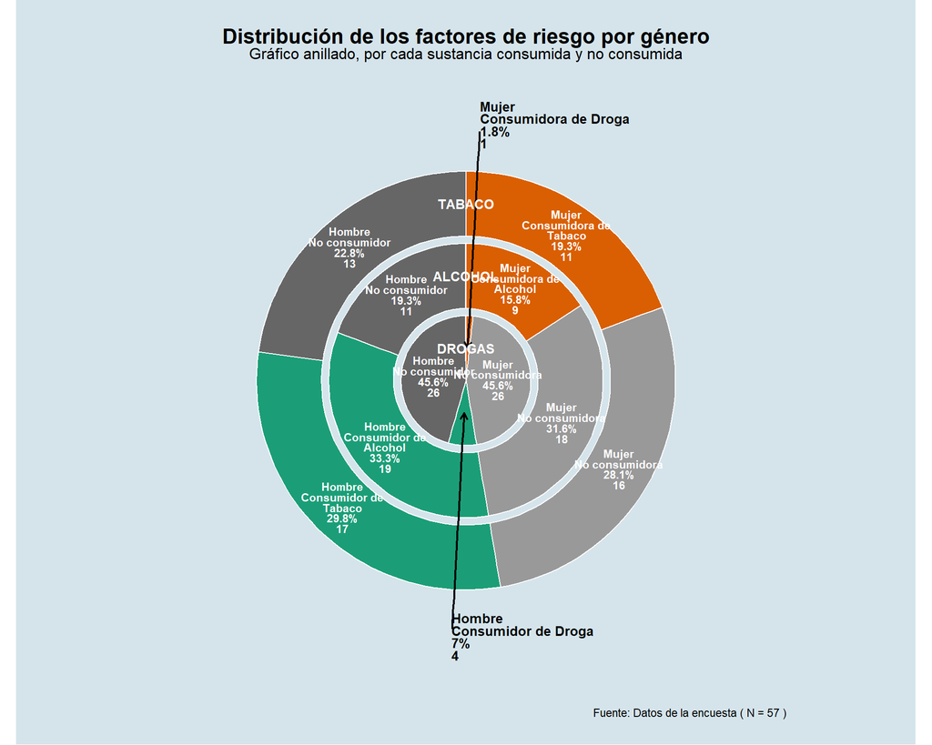

```r
library(ggthemes)
#Creación de la data_riesgo
data_riesgo <- data %>%
  mutate(
    consumo_tabaco = case_when(
      ccr_h_tabac %in% c("Fumo actualmente", "Fumé en el pasado") ~ "Sí",
      ccr_h_tabac %in% c("Nunca fumé") ~ "No",
      TRUE ~ NA
    ),
    consumo_alcohol = case_when(
      ccr_h_alc == "Moderado" ~ "Sí",
      ccr_h_alc == "Ninguno" ~ "No",
      TRUE ~ NA
    ),
    consumo_drogas = case_when(
      ccr_h_drogas == "Sí" ~ "Sí",
      ccr_h_drogas == "No" ~ "No",
      TRUE ~ NA
    )
  ) %>%
  select(genero, consumo_tabaco, consumo_alcohol, consumo_drogas) %>%
  pivot_longer(cols = starts_with("consumo"),
               names_to = "riesgo", values_to = "consumo") %>%
  mutate(
    riesgo = recode(riesgo,
                    "consumo_tabaco" = "Tabaco",
                    "consumo_alcohol" = "Alcohol",
                    "consumo_drogas" = "Drogas"),
    #Orden según la sustancia de riesgo
    riesgo = factor(riesgo, levels = c("Drogas", "Alcohol", "Tabaco")),
    grupo = paste(genero, consumo, sep = "_")
  ) %>%
  group_by(riesgo, grupo, genero, consumo) %>%
  summarise(n = n(), .groups = "drop") %>%
  group_by(riesgo) %>%
  mutate(pct = n / sum(n) * 100) %>%
  arrange(riesgo, rev(grupo)) %>%
  mutate(
    y_pos = cumsum(pct) - (0.5 * pct),

    #Etiquetas externas
    etiqueta_externa = case_when(
      riesgo == "Drogas" & consumo == "Sí" & genero == "Hombre" ~ "Hombre\nConsumidor de Droga",
      riesgo == "Drogas" & consumo == "Sí" & genero == "Mujer" ~ "Mujer\nConsumidora de Droga",
      TRUE ~ NA_character_
    ),

    #Etiquetas internas
    etiqueta_interna = ifelse(is.na(etiqueta_externa),
                              paste0(
                                case_when(
                                  grepl("Hombre_No", grupo) ~ "Hombre\nNo consumidor",
                                  grepl("Mujer_No", grupo) ~ "Mujer\nNo consumidora",
                                  grupo == "Hombre_Sí" ~ paste0("Hombre\nConsumidor de\n", as.character(riesgo)),
                                  grupo == "Mujer_Sí" ~ paste0("Mujer\nConsumidora de\n", as.character(riesgo))
                                ),
                                "\n", round(pct, 1), "%\n", n
                              ), NA)
  )

#Diferenciación por colores
colores <- c(
  "Hombre_Sí" = "#1B9E77",
  "Mujer_Sí" = "#D95F02",
  "Hombre_No" = "gray40",
  "Mujer_No" = "gray60"
)

#creación Gráfico Anillado
anillo_plot <- ggplot(data_riesgo, aes(x = riesgo, y = pct, fill = grupo)) +
  geom_col(color = "white", width = 0.9) +

  #Etiquetas Internas
  geom_text(
    aes(label = etiqueta_interna, y = y_pos),
    color = "white", fontface = "bold", size = 3, lineheight = 0.8
  ) +

  # B) LÍNEAS DIRECCIONALES
  geom_segment(
    data = subset(data_riesgo, !is.na(etiqueta_externa)),
    aes(x = 1, xend = 4, y = y_pos, yend = y_pos),
    color = "black", size = 0.8,
    arrow = arrow(length = unit(0.2, "cm"), ends = "first")
  ) +

  # C) ETIQUETAS EXTERNAS
  geom_text(
    data = subset(data_riesgo, !is.na(etiqueta_externa)),
    aes(label = paste0(etiqueta_externa, "\n", round(pct, 1), "%\n", n),
        x = 4.1, y = y_pos),
    color = "black", fontface = "bold", size = 3.5, lineheight = 0.8, hjust = 0
  ) +

  # Configuración
  coord_polar(theta = "y") +
  scale_fill_manual(values = colores) +

  # Anotaciones
  annotate("text", x = 3, y = 0, label = "TABACO", hjust = 0.5, size = 3.5, fontface = "bold", color = "white") +
  annotate("text", x = 2, y = 0, label = "ALCOHOL", hjust = 0.5, size = 3.5, fontface = "bold", color = "white") +
  annotate("text", x = 1, y = 0, label = "DROGAS", hjust = 0.5, size = 3.5, fontface = "bold", color = "white") +

  labs(title = "Distribución de los factores de riesgo por género",
       subtitle = "Gráfico anillado, por cada sustancia consumida y no consumida",
       caption = "Fuente: Datos de la encuesta ( N = 57 )"
  ) +

  theme_economist() +
  theme(
    legend.position = "none",
    plot.title = element_text(face = "bold", hjust = .5, size = 16),
    plot.subtitle = element_text(hjust = .5, size = 12),
    plot.margin = margin(t = 20, r = 100, b = 20, l = 100),
    axis.title = element_blank(),
    axis.text = element_blank(),
    axis.ticks = element_blank(),
    panel.grid = element_blank(),
    axis.line = element_blank())

anillo_plot
```

*Conclusiones del Perfil de factores de riesgo de la muestra*

El análisis visual de la distribución de factores de riesgo revela patrones de comportamiento distintivos que permiten una segmentación clara de la muestra:

**Asimetría por Género:** Existe una brecha de género significativa en la prevalencia de consumo. Los hombres presentan una mayor carga de riesgo, dominando porcentualmente tanto en el consumo de Alcohol (33.3% vs 15.8% en mujeres) como en el de Tabaco (29.8% vs 19.3%).

## Factores protectores

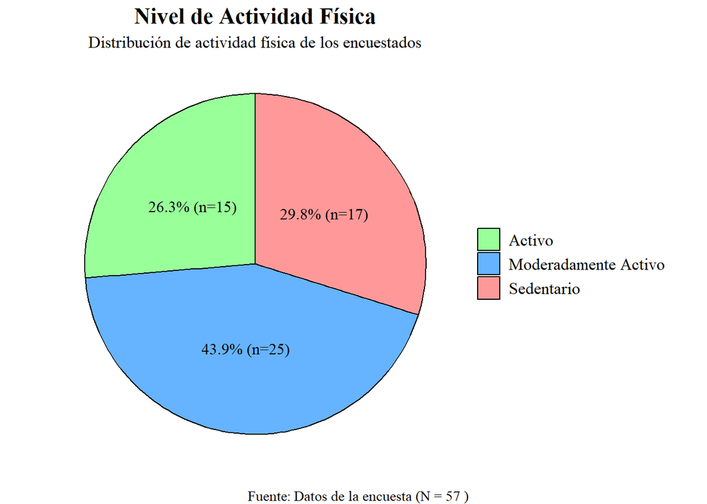

```r
# ==============================================================================
# 1. PREPARACIÓN DE DATOS (Adaptado para Actividad Física)
# ==============================================================================
data_fp <- data %>%
  mutate(
    # Convertimos a caracter por seguridad
    ccr_p_act = as.character(ccr_p_act),

    # Lógica de limpieza y estandarización
    ccr_p_act_clean = case_when(
      # Detectamos "Sedentario"
      grepl("Sedentario", ccr_p_act, ignore.case = TRUE) ~ "Sedentario",

      # Detectamos "Moderadamente" (asumiendo "Moderadamente activo")
      grepl("Moderad", ccr_p_act, ignore.case = TRUE) ~ "Moderadamente Activo",

      # Detectamos "Activo" (cuidado de no solapar con Moderadamente activo,
      # el orden del case_when importa, pero grepl es específico)
      # Buscamos "Activo" puro o que empiece con Activo si fuera el caso
      grepl("^Activo", ccr_p_act, ignore.case = TRUE) ~ "Activo",

      # Mantenemos original por defecto
      TRUE ~ ccr_p_act
    )
  )

# ==============================================================================
# 2. DEFINICIÓN DE COLORES
# ==============================================================================
colores_actividad <- c(
  "Sedentario"           = "#ff9999",  # Rojo suave (Riesgo)
  "Moderadamente Activo" = "#66b3ff",  # Azul suave (Intermedio/Estándar)
  "Activo"               = "#99ff99"   # Verde suave (Positivo)
)

# ==============================================================================
# 3. GENERACIÓN DEL GRÁFICO
# ==============================================================================
datos_grafico_fp <- data_fp %>%
  # Filtramos categorías válidas
  filter(!is.na(ccr_p_act_clean) & ccr_p_act_clean %in% c("Sedentario", "Moderadamente Activo", "Activo")) %>%
  count(ccr_p_act_clean) %>%
  mutate(
    porcentaje = n / sum(n),
    etiqueta = paste0(percent(porcentaje, accuracy = 0.1), " (n=", n, ")")
  )

# Calculamos N total
total_encuestados_act <- sum(datos_grafico_fp$n)

ggplot(datos_grafico_fp, aes(x = "", y = porcentaje, fill = ccr_p_act_clean)) +
  geom_bar(stat = "identity", width = 1, color = "black", linewidth = 0.5) +
  coord_polar("y", start = 0) +
  scale_fill_manual(values = colores_actividad) +
  geom_text(aes(label = etiqueta),
            position = position_stack(vjust = 0.5),
            color = "black",
            family = "serif",
            size = 4) +
  theme_void() +
  theme(
    text = element_text(family = "serif"),
    plot.title = element_text(hjust = 0.5, size = 16, face = "bold"),
    plot.subtitle = element_text(hjust = 0.5, size = 12),
    plot.caption = element_text(hjust = 1, size = 10, margin = margin(t = 10)),
    legend.title = element_blank(),
    legend.text = element_text(size = 12),
    legend.position = "right"
  ) +
  labs(title = "Nivel de Actividad Física",
       subtitle = "Distribución de actividad física de los encuestados",
       caption = paste("Fuente: Datos de la encuesta (N =", total_encuestados_act, ")")
  )
```

## Análisis del Riesgo

La variable riesgo sintetiza la evaluación clínica. A continuación, se visualiza la distribución de los encuestados en las tres categorías de alerta.

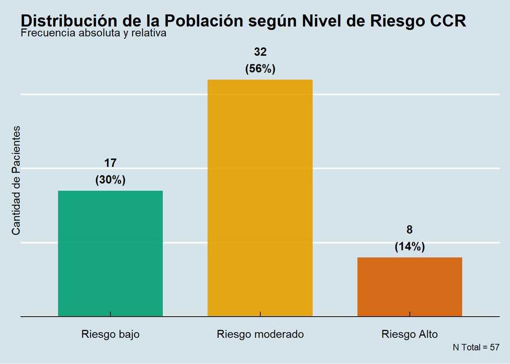

```r
# Preparación de etiquetas informativas
data_riesgo <- data %>%
  count(riesgo) %>%
  mutate(
    pct = n / sum(n),
    etiqueta = paste0(n, "\n(", percent(pct, accuracy = 1), ")")
  )

# Gráfico de Barras
ggplot(data_riesgo, aes(x = riesgo, y = n, fill = riesgo)) +
  geom_col(width = 0.7, alpha = 0.9) +
  geom_text(aes(label = etiqueta), vjust = -0.3, fontface = "bold", size = 4) +

  # Escala de colores (escala semáforo)
  scale_fill_manual(values = c("Riesgo bajo" = "#009E73",
                               "Riesgo moderado" = "#E69F00",
                               "Riesgo Alto" = "#D55E00")) +
  labs(
    title = "Distribución de la Población según Nivel de Riesgo CCR",
    subtitle = "Frecuencia absoluta y relativa",
    x = NULL, y = "Cantidad de Pacientes",
    caption = paste("N Total =", sum(data_riesgo$n))
  ) +
  theme_economist() +
  theme(legend.position = "none", axis.text.y = element_blank()) +
  scale_y_continuous(expand = expansion(mult = c(0, 0.15)))
```

La visualización permite identificar rápidamente la carga de enfermedad potencial. Los grupos “Moderado” y “Alto” son prioritarios para derivación a colonoscopía o test de sangre oculta (TSOH), conforme a las guías del MINSAL.

La presencia de síntomas como rectorragia o pérdida de peso involuntaria suele indicar patología avanzada. Aquí analizamos la cantidad de síntomas y su tipo.

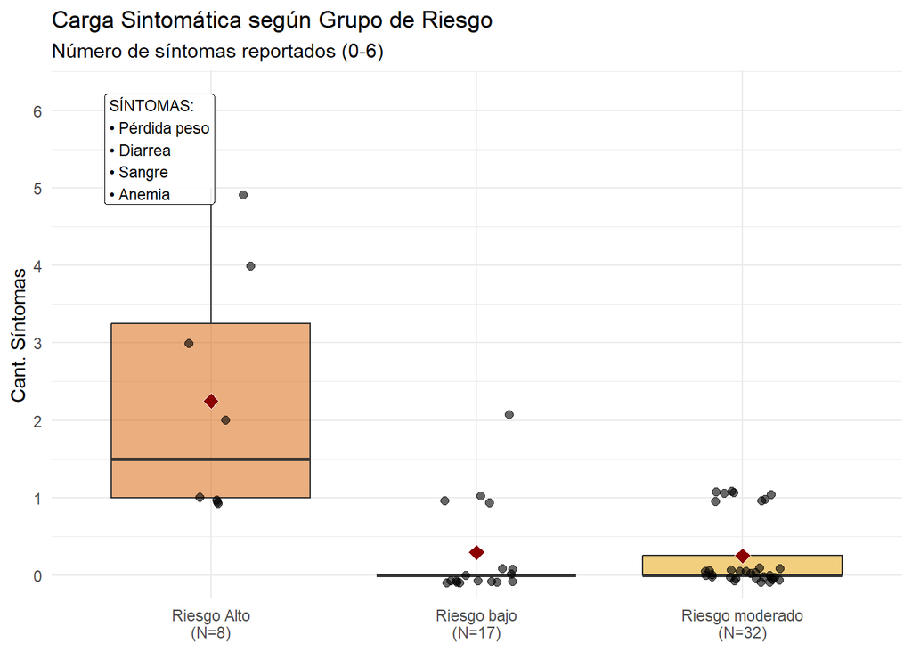

```r
# 1. Definir columnas de síntomas clínicos
sintomas_cols <- c("ccr_c_peso", "ccr_c_diar", "ccr_c_estr",
                   "ccr_c_sangre", "ccr_c_anemia", "ccr_c_masa")

# 2. Cálculo de síntomas por paciente (Normalizando "Si" y "Sí")
data_sintomas <- data %>%
  rowwise() %>%
  mutate(n_sintomas = sum(c_across(all_of(sintomas_cols)) %in% c("Si", "Sí"), na.rm = TRUE)) %>%
  ungroup()

# 3. Etiquetas eje X con N
data_grafico <- data_sintomas %>%
  add_count(riesgo, name = "n_riesgo") %>%
  mutate(etiqueta_x = paste0(riesgo, "\n(N=", n_riesgo, ")"))

# 4. Texto explicativo
texto_sintomas <- paste("SÍNTOMAS:", "• Pérdida peso", "• Diarrea", "• Sangre", "• Anemia", sep = "\n")

# Visualización
ggplot(data_grafico, aes(x = etiqueta_x, y = n_sintomas, fill = riesgo)) +
  geom_boxplot(alpha = 0.5, outlier.shape = NA) +
  geom_jitter(width = 0.15, height = 0.1, alpha = 0.6, size = 2) +

  # Media (Rombo rojo)
  stat_summary(fun = mean, geom = "point", shape = 23, size = 3, fill = "darkred", color = "white") +
   # Anotación
  annotate("label", x = 0.6, y = 5.5, label = texto_sintomas, hjust=0, size=3, alpha=0.9) +

  scale_y_continuous(breaks = seq(0, 6, 1)) +
  scale_fill_manual(values = c("#009E73", "#E69F00", "#D55E00")) +

  labs(title = "Carga Sintomática según Grupo de Riesgo",
       subtitle = "Número de síntomas reportados (0-6)", x = NULL, y = "Cant. Síntomas") +
  theme_minimal() + theme(legend.position = "none") +
    coord_cartesian(ylim = c(0, 6.2))
```

El gráfico Lollipop jerarquiza los motivos de consulta. Detectar una alta prevalencia de síntomas específicos (como estreñimiento o sangre) ayuda a dirigir la educación sanitaria hacia esos signos de alerta temprana.

```r
# Transformación de datos para ranking
sintomas_map <- c("ccr_c_peso"="Pérdida Peso", "ccr_c_diar"="Diarrea", "ccr_c_estr"="Estreñimiento",
                  "ccr_c_sangre"="Sangre Heces", "ccr_c_anemia"="Anemia", "ccr_c_masa"="Masa Abd.")

data_rank <- data %>%
  select(all_of(names(sintomas_map))) %>%
  pivot_longer(everything(), names_to = "cod", values_to = "resp") %>%
  filter(resp %in% c("Si", "Sí")) %>%
  count(cod) %>%
  mutate(
    nombre = sintomas_map[cod],
    pct = n / nrow(data),
    etiqueta = paste0(percent(pct, accuracy = 1), " (n=", n, ")")
  )

lollyplot <- ggplot(data_rank, aes(x = pct, y = reorder(nombre, pct))) +
  geom_segment(aes(x = 0, xend = pct, yend = nombre), color = "grey") +
  geom_point(size = 5, color = "#D55E00") +
  geom_text(aes(label = etiqueta), hjust = -0.3, size = 3.5, fontface="bold") +
  scale_x_continuous(labels = percent, limits = c(0, max(data_rank$pct)*1.3)) +
  labs(title = "Ranking de Síntomas de Alarma", x = "Prevalencia en la Muestra", y = NULL,
       caption = paste("N Total =", sum(data_rank$n)) )
  theme_economist() +
  theme(panel.grid.major.y = element_blank())
```

[output not shown]

[output not shown]

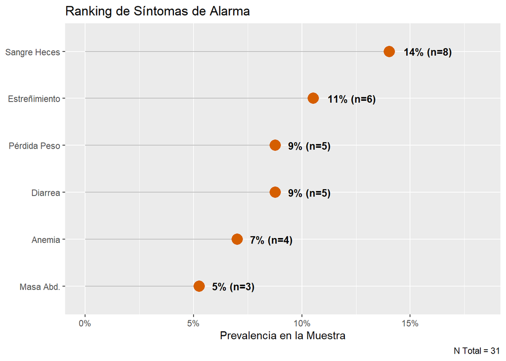

```r
lollyplot
```